# Analysis: Pre/Post Test

## Introduction

This markdown imports the processed data and analyzes the pre/post data. It is broken down into the following sections

- Confidence Results
  - Pre-Survey
  - Post-Survey
- Overall Paired T-test
- Scores by Participant Characteristics
  - Facility-Label
  - Clinical-Non
  - Healthcare-Years
  - Facility-Years
  - Facilities-Number
  - Shift-Type
  - EC-YN
  - Facilities-different-codes
- Scores by Code Opinions
  - PL-codes
  - Code-exceptions
  - Training-Orientation
  - Training-Yearly
  - Training-Exercise
  - Training-OtherCat
  - Training-last-time
  - Code-confusion

## Required Packages

The following R packages are required for this script:

- here: for path setting
- tidyverse: for all packages in the Tidyverse (ggplot2, dyplr, tidyr, readr, purr, tibble, stringr, forcats)
- effsize: for cohen’s d effect size determination
- rstatix: for pairwise comparisons
- ggpubr: for making box plots (potentially)
- extrafont: for changing ggplot fonts

## Load Processed Data

Load the data generated from the markdowns in the `processing_code` folder.

```r
#define file path
data_location <- here::here("data", "processed_data", "combined_processed.rds")

#load data
data_1 <- readRDS(data_location)
```

## Fix Data Cleaning

Remove the observations with 0 facilities

```r
data <- subset(data_1,
                     data_1$`Facilities-Number` != 0)
```

## Confidence Results

First, let’s compare the distributions of the pre-survey and post-survey confidence scores.

### Pre-Survey

```r
#summary statistics
base::summary(data$`Pre-Confidence`)
```

```
##    Min. 1st Qu.  Median    Mean 3rd Qu.    Max.
##   1.000   4.000   5.000   5.362   6.000   7.000
```

```r
sd(data$`Pre-Confidence`)
```

```
## [1] 1.237742
```

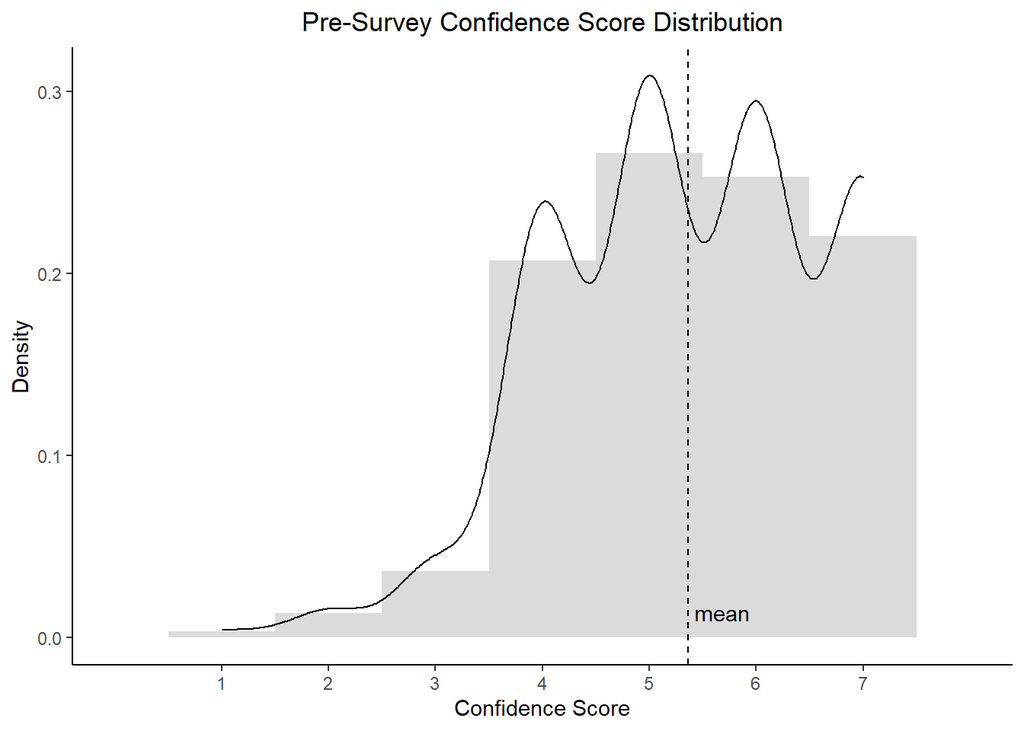

```r
# Density + Histogram
pre_plot <- data %>%
              ggplot(aes(x = `Pre-Confidence`)) +
              geom_histogram(aes(y = ..density..),
                             binwidth = 1,
                             alpha = 0.35,
                             fill = "#999999") +
              geom_density() +
              geom_vline(xintercept = mean(data$`Pre-Confidence`, na.rm=T),
                         linetype = 2) +
              annotate("text", x = mean(data$`Pre-Confidence`, na.rm=T),
                               y = 0,
                               label = " mean",
                               vjust = -1,
                               hjust = 0) +
              scale_x_continuous(breaks = seq(1, 7, by = 1)) +
              coord_cartesian(xlim = c(0,8)) +
              labs(y = "Density",
                   x = "Confidence Score",
                   title="Pre-Survey Confidence Score Distribution")

pre_plot
```

```r
#save plot
pre_conf_plot = here::here("results", "prepost", "pre_conf_plot.png")
ggsave(filename = pre_conf_plot,
       plot = pre_plot,
       dpi = 300)
```

### Post-Survey

```r
#summary statistics
base::summary(data$`Post-Confidence`)
```

```
##    Min. 1st Qu.  Median    Mean 3rd Qu.    Max.
##   1.000   3.000   5.000   4.493   6.000   7.000
```

```r
sd(data$`Post-Confidence`)
```

```
## [1] 1.547901
```

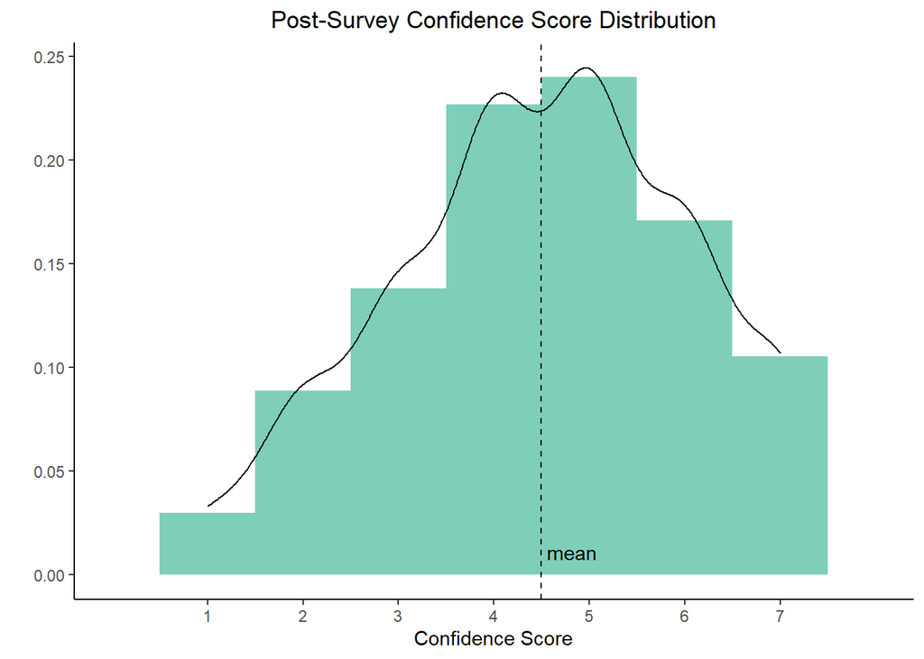

```r
# Density + Histogram
post_plot <- data %>%
              ggplot(aes(x = `Post-Confidence`)) +
              geom_histogram(aes(y = ..density..),
                             binwidth = 1,
                             alpha = 0.5,
                             fill = "#009E73") +
              geom_density() +
              geom_vline(xintercept = mean(data$`Post-Confidence`, na.rm=T),
                         linetype = 2) +
              annotate("text", x = mean(data$`Post-Confidence`, na.rm=T),
                               y = 0,
                               label = " mean",
                               vjust = -1,
                               hjust = 0) +
              scale_x_continuous(breaks = seq(1, 7, by = 1)) +
              coord_cartesian(xlim = c(0,8)) +
              labs(y = "",
                   x = "Confidence Score",
                   title="Post-Survey Confidence Score Distribution")

post_plot
```

```r
#save plot
post_conf_plot = here::here("results", "prepost", "post_conf_plot.png")
ggsave(filename = post_conf_plot,
       plot = post_plot,
       dpi = 300)
```

### Compare on Same Plot

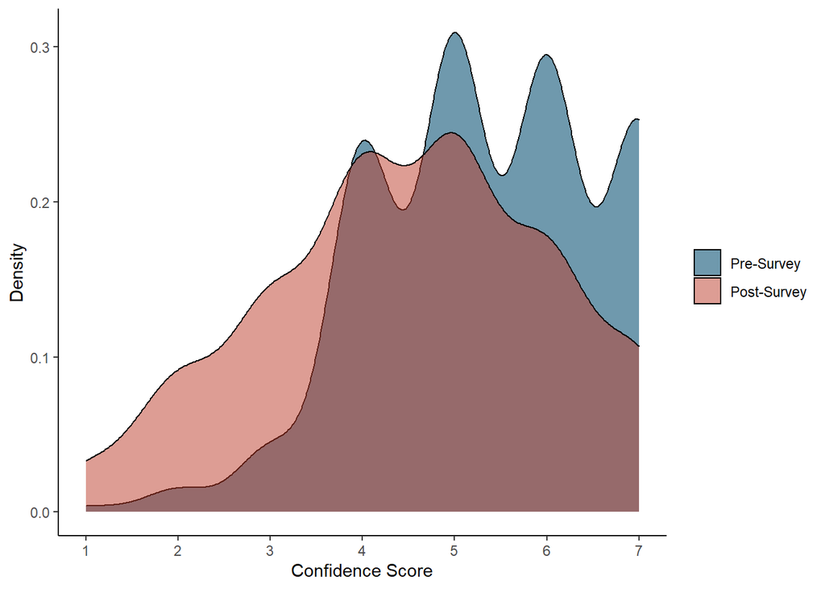

```r
#first rearrange columns to put pre and post next to each other
data_1 <- data %>%
                dplyr::select(`Facility-Label`:`Shift-Type`,
                              `Fire-Type`:`Code-confusion`,
                              `Pre-Confidence`,
                              `Post-Confidence`)

#convert to long format in order to be able to plot all three outcomes with the same variable
data_1_long <- tidyr::gather(data_1, TestCat, score, `Pre-Confidence`:`Post-Confidence`, factor_key = TRUE)

#change labels
levels(data_1_long$TestCat) <- c("Pre-Survey", "Post-Survey")

#make df for mean scores
data_2_long <- data_1_long %>%
                  dplyr::group_by(TestCat) %>%
                  dplyr::summarise(Mean.score = mean(score))

#add label column to data_2_long
data_2_long$ScoreAvg <- sub("^", "Mean = ", round(data_2_long$Mean.score, digits = 2))

#plot density curves on same plot
base_plot <- ggplot2::ggplot(data = data_1_long, aes(x = score)) +
                      geom_density(aes(fill = TestCat,
                                       alpha = TestCat)) +
                         scale_fill_manual(values = c("#6F99ADFF", "#BC3C29FF")) +
                         scale_alpha_manual(values = c(1, 0.5)) +
                         scale_x_continuous(breaks = seq(1, 7, by = 1)) +
                         theme(legend.title = element_blank()) +
                         labs(y = "Density",
                              x = "Confidence Score")
base_plot
```

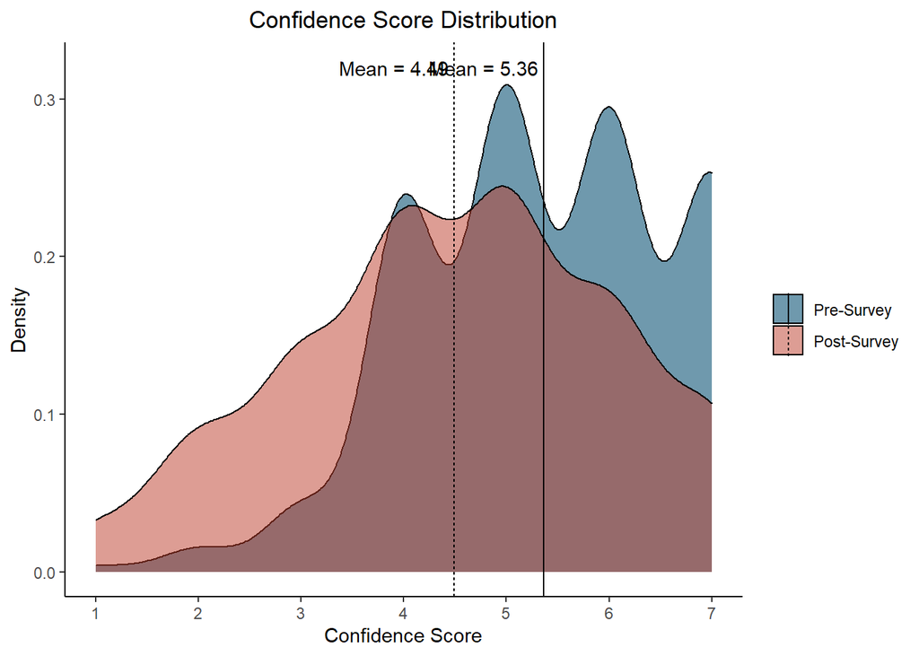

```r
#add the mean line separately so that it can be adjusted later with other variables
both_plot <- base_plot + geom_vline(data = data_2_long,
                                    mapping = aes(xintercept = Mean.score,
                                                  linetype = TestCat)) +
                         geom_text(data = data_2_long,
                                   aes(x = Mean.score, y = 0.32, label = ScoreAvg),
                                   hjust = 1.05) +
                         labs(title = "Confidence Score Distribution")

both_plot
```

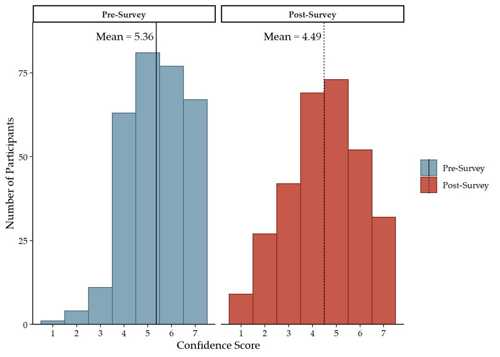

```r
#save plot
both_conf_plot = here::here("results", "prepost", "both_conf_plot.png")
ggsave(filename = both_conf_plot,
       plot = both_plot,
       dpi = 300)
both_plot2 <- data_1_long %>%
                ggplot(aes(x = score)) +
                geom_histogram(aes(y = ..count..,
                                   fill = TestCat,
                                   colour = TestCat),
                               binwidth = 1,
                               alpha = 0.85) +
                facet_wrap(~ TestCat) +
                scale_fill_manual(values = c("#6F99ADFF", "#BC3C29FF")) +
                scale_color_manual(values = c("#4A6673", "#7D281B")) +
                scale_x_continuous(breaks = seq(1, 7, by = 1)) +
                scale_y_continuous(expand = c(0,0),
                                   limits = c(0, 90)) +
                coord_cartesian(xlim = c(0.5, 7.5)) +
                labs(y = "Number of Participants",
                     x = "Confidence Score") +
                theme(strip.text.x = element_text(face = "bold"),
                      legend.title = element_blank(),
                      text = element_text(family = "Palatino Linotype"),
                      axis.text = element_text(color = "black")) +
                geom_vline(data = data_2_long,
                           mapping = aes(xintercept = Mean.score,
                                         linetype = TestCat)) +
                geom_text(data = data_2_long,
                          aes(x = Mean.score, y = 86, label = ScoreAvg),
                          hjust = 1.05,
                          family = "Palatino Linotype")
both_plot2
```

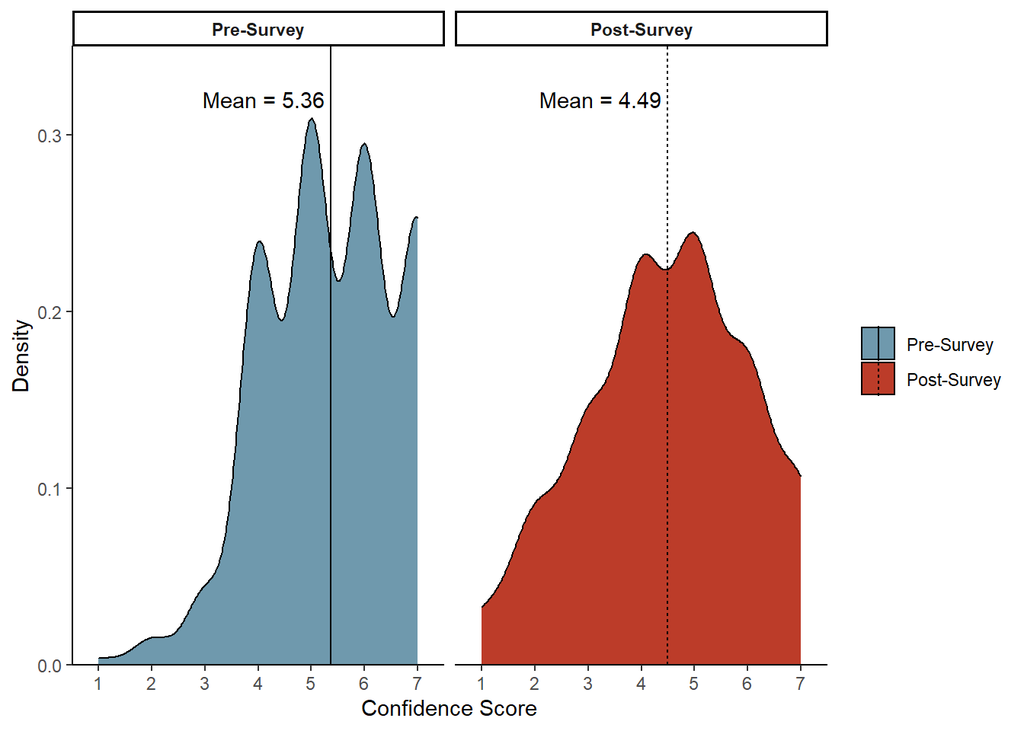

```r
#save plot
both_conf_plot2 = here::here("results", "prepost", "both_conf_plot_hist.png")
ggsave(filename = both_conf_plot2,
       plot = both_plot2,
       dpi = 300)
both_plot3 <- data_1_long %>%
                ggplot2::ggplot(aes(x = score)) +
                         geom_density(aes(fill = TestCat)) +
                         facet_wrap(~ TestCat) +
                         scale_fill_manual(values = c("#6F99ADFF", "#BC3C29FF")) +
                         scale_alpha_manual(values = c(1, 0.5)) +
                         scale_x_continuous(breaks = seq(1, 7, by = 1)) +
                         scale_y_continuous(expand = c(0,0),
                                            limits = c(0, 0.35)) +
                         coord_cartesian(xlim = c(0.5, 7.5),
                                         expand = FALSE) +
                         theme(legend.title = element_blank()) +
                         theme(strip.text.x = element_text(face = "bold")) +
                         labs(y = "Density",
                              x = "Confidence Score") +
                         geom_vline(data = data_2_long,
                                    mapping = aes(xintercept = Mean.score,
                                                  linetype = TestCat)) +
                         geom_text(data = data_2_long,
                                   aes(x = Mean.score, y = .32, label = ScoreAvg),
                                   hjust = 1.05)
both_plot3
```

```r
#save plot
both_conf_plot3 = here::here("results", "prepost", "both_conf_plot_dist.png")
ggsave(filename = both_conf_plot3,
       plot = both_plot3,
       dpi = 300)
```

## Paired Student’s T-Test

The Paired Student’s T-Test will tell us if there is a significant difference between the pre/post survey confidence scores, and the Cohen’s D metric determines the effect size.

```r
#two-sided paired t-test
stats::t.test(data$`Pre-Confidence`, data$`Post-Confidence`, paired = T)
```

```
##
##  Paired t-test
##
## data:  data$`Pre-Confidence` and data$`Post-Confidence`
## t = 13.005, df = 303, p-value < 0.00000000000000022
## alternative hypothesis: true mean difference is not equal to 0
## 95 percent confidence interval:
##  0.7370166 0.9998255
## sample estimates:
## mean difference
##       0.8684211
```

```r
#determine effect size (Cohen's D)
effsize::cohen.d(data$`Post-Confidence`, data$`Pre-Confidence`, paired = T, na.rm = T)
```

```
##
## Cohen's d
##
## d estimate: -0.6047275 (medium)
## 95 percent confidence interval:
##      lower      upper
## -0.7040468 -0.5054082
```

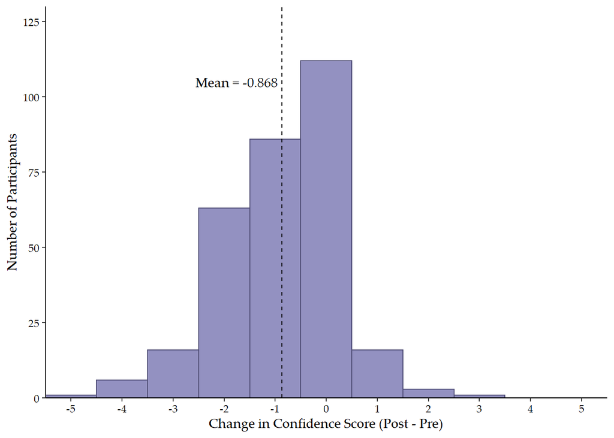

```r
#assumptions check:
#1. the differences are independently distributed
#we know this is true because data are not clustered, time-series, or spatial

#2. the differences are normally distributed
#we can check this with a histogram of the differences

#compute the mean difference and assign it to a variable
mean_diff <- mean(data$`Post-Confidence`-data$`Pre-Confidence`)

#make df for mean scores
data_2_long <- data_1_long %>%
                  dplyr::group_by(TestCat) %>%
                  dplyr::summarise(Mean.score = mean(score))

#convert mean_diff to a dataframe
mean_diff <- as.data.frame(mean_diff)

#add label column
mean_diff$lbl <- sub("^", "Mean = ", round(mean_diff$mean_diff, digits = 3))

diff_plot <- data %>%
              ggplot2::ggplot(aes(x = `Post-Confidence`-`Pre-Confidence`)) +
                       geom_histogram(aes(y = ..count..),
                                      binwidth = 1,
                                      alpha = .8,
                                      fill = "#7876B1FF",
                                      colour = "#504e76") +
                       scale_x_continuous(breaks = seq(-5, 5, by = 1)) +
                       coord_cartesian(xlim = c(-5,5)) +
                       scale_y_continuous(expand = c(0,0),
                                          limits = c(0, 130)) +
                       labs(y = "Number of Participants",
                            x = "Change in Confidence Score (Post - Pre)") +
                       geom_vline(data = mean_diff,
                                  mapping = aes(xintercept = mean_diff),
                                  linetype = 2) +
                       geom_text(data = mean_diff,
                                   aes(x = mean_diff, y = 105, label = lbl),
                                   hjust = 1.05,
                                   family = "Palatino Linotype") +
                       theme(axis.text = element_text(color = "black"),
                             text = element_text(family = "Palatino Linotype"))
diff_plot
```

```r
#save plot
diff_conf_plot = here::here("results", "prepost", "diff_conf_plot.png")
ggsave(filename = diff_conf_plot,
       plot = diff_plot,
       dpi = 300)
#central limit theorem says that even if the data are not normally distributed, the sample mean will be approximately normally distributed
#the paired t-test is robust to violations of the assumption of normality
#therefore, regardless, the paired t-test can proceed if n > 30
```

Mean of the differences = 0.868 reduction in confidence score (95% CI of the change = 0.737, 0.999)

Conclusion: For this sample of 304 participants, completing the survey resulted in a decrease in confidence of code knowledge (t = 13.005; df = 303, p < 0.001) by 0.868 points (95% CI: 0.737, 0.999).

Cohen’s d suggests the pre/post groups differ by -0.605 standard deviations, which is a “medium” effect (i.e. probably big enough to discern with the naked eye but not guaranteed).

## Scores by Participant Characteristics

We want to know if the distribution of confidence scores varies (significantly) by any of the participant characteristics. The following variables will be analyzed:

- Facility-Label
- Clinical-Non
- Healthcare-Years
- Facility-Years
- Facilities-Number
- Shift-Type
- EC-YN
- Facilities-different-codes

The following steps will be followed for each variable:

1. Visualization: Pre/Post Density Plot
2. Pairwise t-test (with a bonferroni correction)
3. Visualization: Box Plot with p-values

The density plot visualization will just build off of the `base_plot` developed above.

To make the pairwise comparisons easier, we can add a variable that is the difference between the post-survey and pre-survey confidence scores (`Delta = Post - Pre`).

```r
#create a shadow df
data_pairwise <- data_1

#create "delta" variable
data_pairwise$delta <- data_pairwise$`Post-Confidence`-data_pairwise$`Pre-Confidence`

#remove dash in column names
names(data_pairwise) <- gsub("-", "", names(data_pairwise))
```

### Facility-Label

1. Density plot of pre- and post-survey confidence scores

```r
#create a named character vector for facility labels
facility_labels <- c(`A` = "Facility A",
                     `B` = "Facility B",
                     `C` = "Facility C",
                     `D` = "Facility D",
                     `E` = "Facility E")

#make a df for mean scores by facility
data_long_facility <- data_1_long %>%
                        dplyr::group_by(TestCat, `Facility-Label`) %>%
                        dplyr::summarise(Mean.score = mean(score))
```

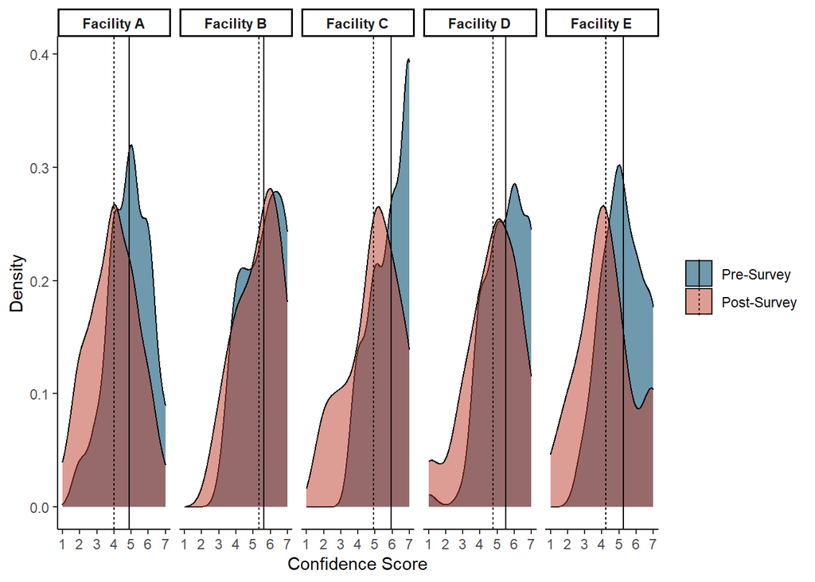

```r
#add a facet wrap to base plot for facility and lines for mean scores
#linetype for the mean confidence score varies by pre/post survey
facility_plot <- base_plot + ggplot2::facet_wrap(. ~ `Facility-Label`,
                                                 labeller = as_labeller(facility_labels),
                                                 nrow = 1) +
                                      theme(strip.text.x = element_text(face = "bold")) +
                                      geom_vline(data = data_long_facility,
                                                 mapping = aes(xintercept = Mean.score,
                                                               linetype = TestCat))

facility_plot
```

```r
#save plot with wider dimensions
facility_conf_plot = here::here("results", "prepost", "facility_conf_plot.png")
ggsave(filename = facility_conf_plot,
       plot = facility_plot,
       width = 12, height = 6, dpi = 300)
```

2. Pairwise T-test by facility

```r
#summary statistics
facility_sum_stats <- data_pairwise %>%
                        dplyr::group_by(FacilityLabel) %>%
                        rstatix::get_summary_stats(delta, type = "mean_sd")
facility_sum_stats
```

```
## # A tibble: 5 x 5
##   FacilityLabel variable     n   mean    sd
##   <chr>         <chr>    <dbl>  <dbl> <dbl>
## 1 A             delta       99 -0.899 1.23
## 2 B             delta       21 -0.286 0.644
## 3 C             delta       59 -1.03  1.02
## 4 D             delta       78 -0.769 1.28
## 5 E             delta       47 -1.02  1.11
```

```r
#compare mean of facilities using ANOVA
facilityaov <- data_pairwise %>% rstatix::anova_test(delta ~ FacilityLabel)
```

```
## Coefficient covariances computed by hccm()
```

```r
facilityaov
```

```
## ANOVA Table (type II tests)
##
##          Effect DFn DFd F     p p<.05   ges
## 1 FacilityLabel   4 299 2 0.094       0.026
```

```r
#pairwise comparison by facility
pwcfacility <- data_pairwise %>%
                  rstatix::pairwise_t_test(delta ~ FacilityLabel, p.adjust.method = "bonferroni")
pwcfacility
```

```
## # A tibble: 10 x 9
##    .y.   group1 group2    n1    n2      p p.signif p.adj p.adj.signif
##  * <chr> <chr>  <chr>  <int> <int>  <dbl> <chr>    <dbl> <chr>
##  1 delta A      B         99    21 0.0281 *        0.281 ns
##  2 delta A      C         99    59 0.479  ns       1     ns
##  3 delta B      C         21    59 0.0114 *        0.114 ns
##  4 delta A      D         99    78 0.459  ns       1     ns
##  5 delta B      D         21    78 0.0901 ns       0.901 ns
##  6 delta C      D         59    78 0.186  ns       1     ns
##  7 delta A      E         99    47 0.551  ns       1     ns
##  8 delta B      E         21    47 0.016  *        0.16  ns
##  9 delta C      E         59    47 0.956  ns       1     ns
## 10 delta D      E         78    47 0.239  ns       1     ns
```

The overall Facility “effect” is not significant. While there is a significant difference between facilities B and C, it is no longer significant after a Bonferroni correction.

3. Visualization: Box Plot with P-values

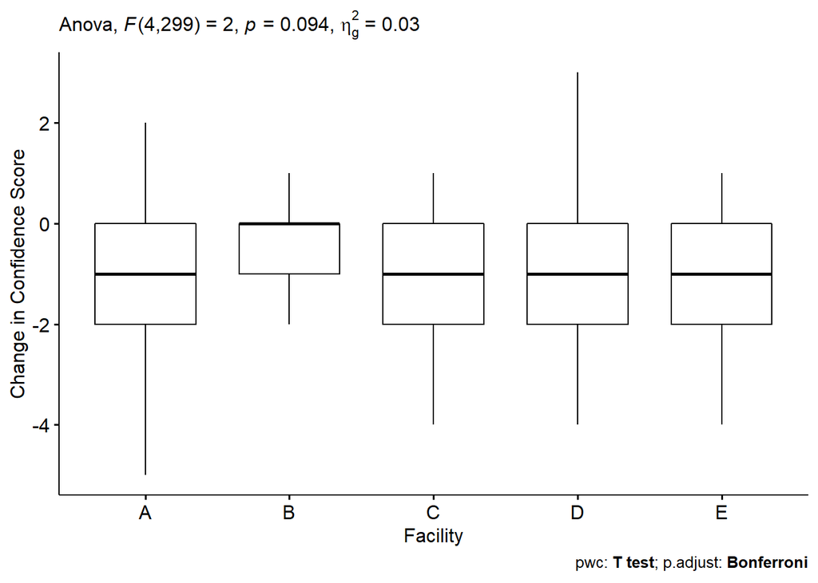

```r
#show significant levels
#hide non-significant tests

pwc_facility_plot <- ggpubr::ggboxplot(data_pairwise, x = "FacilityLabel", y = "delta") +
                     ggpubr::stat_pvalue_manual(pwcfacility,
                                                hide.ns = TRUE,
                                                label = "p.adj",
                                                y.position = 0.15,
                                                step.increase = 0.2) +
                             labs(x = "Facility",
                                  y = "Change in Confidence Score",
                                  subtitle = rstatix::get_test_label(facilityaov, detailed = TRUE),
                                  caption = rstatix::get_pwc_label(pwcfacility))
pwc_facility_plot
```

```r
#save plot with wider dimensions
pwcfacility_plot = here::here("results", "prepost", "pwc_facility_plot.png")
ggsave(filename = pwcfacility_plot,
       plot = pwc_facility_plot,
       dpi = 300)
```

### Clinical-Non

1. Density plot of pre- and post-survey confidence scores

```r
#make a df for mean scores by role type
data_long_clinical <- data_1_long %>%
                        dplyr::group_by(TestCat, `Clinical-Non`) %>%
                        dplyr::summarise(Mean.score = mean(score))
```

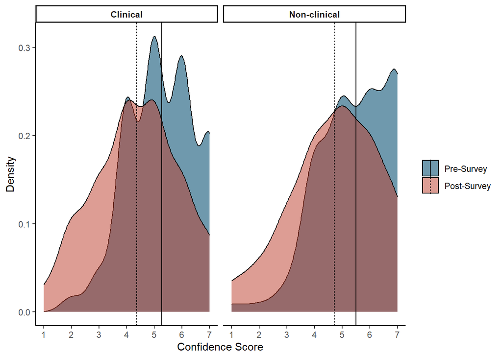

```r
#add a facet wrap to base plot for clinical and lines for mean scores
#linetype for the mean confidence score varies by pre/post survey
clinical_plot <- base_plot + ggplot2::facet_wrap(. ~ `Clinical-Non`) +
                                      theme(strip.text.x = element_text(face = "bold")) +
                                      geom_vline(data = data_long_clinical,
                                                 mapping = aes(xintercept = Mean.score,
                                                               linetype = TestCat))

clinical_plot
```

```r
#save plot
clinical_conf_plot = here::here("results", "prepost", "clinical_conf_plot.png")
ggsave(filename = clinical_conf_plot,
       plot = clinical_plot,
       dpi = 300)
```

2. Pairwise T-test by Role Type

```r
#summary statistics
clinical_sum_stats <- data_pairwise %>%
                        dplyr::group_by(ClinicalNon) %>%
                        rstatix::get_summary_stats(delta, type = "mean_sd")
clinical_sum_stats
```

```
## # A tibble: 2 x 5
##   ClinicalNon  variable     n   mean    sd
##   <chr>        <chr>    <dbl>  <dbl> <dbl>
## 1 Clinical     delta      196 -0.913  1.14
## 2 Non-clinical delta      108 -0.787  1.22
```

```r
#compare mean of clinical role using ANOVA
clinicalaov <- data_pairwise %>% rstatix::anova_test(delta ~ ClinicalNon)
```

```
## Coefficient covariances computed by hccm()
```

```r
clinicalaov
```

```
## ANOVA Table (type II tests)
##
##        Effect DFn DFd     F     p p<.05   ges
## 1 ClinicalNon   1 302 0.818 0.366       0.003
```

```r
#pairwise comparison by role
pwcclinical <- data_pairwise %>%
                  rstatix::pairwise_t_test(delta ~ ClinicalNon, p.adjust.method = "bonferroni")
pwcclinical
```

```
## # A tibble: 1 x 9
##   .y.   group1   group2          n1    n2     p p.signif p.adj p.adj.signif
## * <chr> <chr>    <chr>        <int> <int> <dbl> <chr>    <dbl> <chr>
## 1 delta Clinical Non-clinical   196   108 0.366 ns       0.366 ns
```

Clinical vs. Non-Clinical is not significant.

3. Visualization: Box Plot with P-values

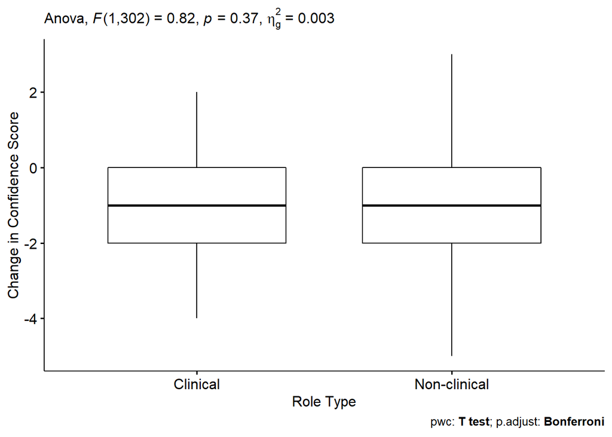

```r
#show significant levels
#hide non-significant tests

pwc_clinical_plot <- ggpubr::ggboxplot(data_pairwise, x = "ClinicalNon", y = "delta") +
                     ggpubr::stat_pvalue_manual(pwcclinical,
                                                hide.ns = TRUE,
                                                label = "p.adj",
                                                y.position = 0.15,
                                                step.increase = 0.2) +
                             labs(x = "Role Type",
                                  y = "Change in Confidence Score",
                                  subtitle = rstatix::get_test_label(clinicalaov, detailed = TRUE),
                                  caption = rstatix::get_pwc_label(pwcclinical))
pwc_clinical_plot
```

```r
#save plot
pwcclinical_plot = here::here("results", "prepost", "pwc_clinical_plot.png")

ggsave(filename = pwcclinical_plot,
       plot = pwc_clinical_plot,
       dpi = 300)
```

### Healthcare-Years

1. Density plot of pre- and post-survey confidence scores

```r
#make a df for mean scores by years in healthcare
data_long_healthcare <- data_1_long %>%
                        dplyr::group_by(TestCat, `Healthcare-Years`) %>%
                        dplyr::summarise(Mean.score = mean(score))
```

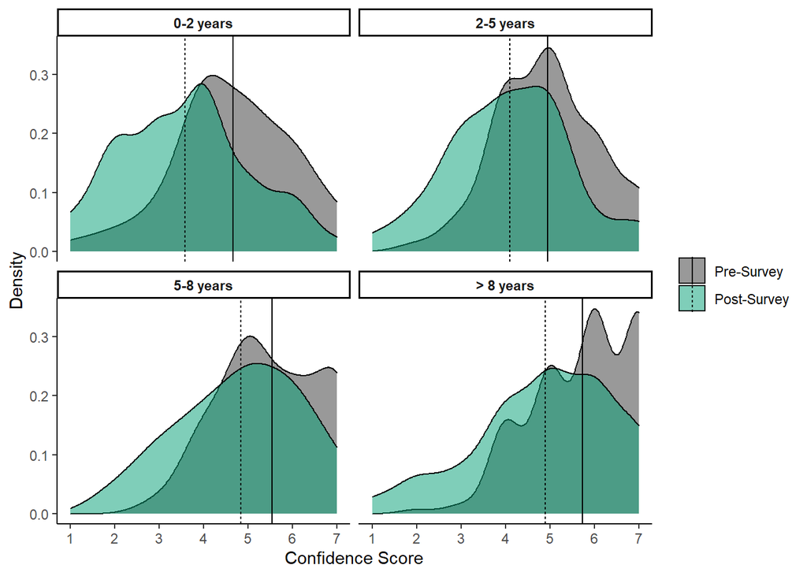

```r
#reorder the levels of healthcare-years using relevel
#replicate data
data_1_long_hc <- data_1_long

#reorder group factor levels
data_1_long_hc$`Healthcare-Years` <- factor(data_1_long_hc$`Healthcare-Years`,
                                            levels = c("0-2 years", "2-5 years", "5-8 years", "> 8 years"))
data_long_healthcare$`Healthcare-Years` <- factor(data_long_healthcare$`Healthcare-Years`,
                                                  levels = c("0-2 years", "2-5 years", "5-8 years", "> 8 years"))


#we have to re-do the whole plot in order to reorder the healthcare years category
#linetype for the mean confidence score varies by pre/post survey
healthcare_plot <- ggplot2::ggplot(data = data_1_long_hc, aes(x = score)) +
                            geom_density(aes(fill = TestCat,
                                             alpha = TestCat)) +
                            scale_fill_manual(values = c("#999999", "#009E73")) +
                            scale_alpha_manual(values = c(1, 0.5)) +
                            scale_x_continuous(breaks = seq(1, 7, by = 1)) +
                            facet_wrap(. ~ `Healthcare-Years`) +
                            geom_vline(data = data_long_healthcare,
                                       mapping = aes(xintercept = Mean.score,
                                                     linetype = TestCat)) +
                            theme(legend.title = element_blank(),
                                  strip.text.x = element_text(face = "bold")) +
                            labs(y = "Density",
                                 x = "Confidence Score")
healthcare_plot
```

```r
#save plot
healthcare_conf_plot = here::here("results", "prepost", "healthcare_conf_plot.png")
ggsave(filename = healthcare_conf_plot,
       plot = healthcare_plot,
       width = 12, height = 6, dpi = 300)
```

2. Pairwise T-test by Years in Healthcare

```r
#summary statistics
healthcare_sum_stats <- data_pairwise %>%
                        dplyr::group_by(HealthcareYears) %>%
                        rstatix::get_summary_stats(delta, type = "mean_sd")
healthcare_sum_stats
```

```
## # A tibble: 4 x 5
##   HealthcareYears variable     n   mean    sd
##   <chr>           <chr>    <dbl>  <dbl> <dbl>
## 1 > 8 years       delta      149 -0.846  1.13
## 2 0-2 years       delta       51 -1.08   1.38
## 3 2-5 years       delta       67 -0.851  1.12
## 4 5-8 years       delta       37 -0.703  1.05
```

```r
#compare mean of healthcare years using ANOVA
healthcareaov <- data_pairwise %>% rstatix::anova_test(delta ~ HealthcareYears)
```

```
## Coefficient covariances computed by hccm()
```

```r
healthcareaov
```

```
## ANOVA Table (type II tests)
##
##            Effect DFn DFd     F     p p<.05   ges
## 1 HealthcareYears   3 300 0.826 0.481       0.008
```

```r
#pairwise comparison by healthcare
pwchealthcare <- data_pairwise %>%
                  rstatix::pairwise_t_test(delta ~ HealthcareYears, p.adjust.method = "bonferroni")
pwchealthcare
```

```
## # A tibble: 6 x 9
##   .y.   group1    group2       n1    n2     p p.signif p.adj p.adj.signif
## * <chr> <chr>     <chr>     <int> <int> <dbl> <chr>    <dbl> <chr>
## 1 delta > 8 years 0-2 years   149    51 0.219 ns       1     ns
## 2 delta > 8 years 2-5 years   149    67 0.976 ns       1     ns
## 3 delta 0-2 years 2-5 years    51    67 0.294 ns       1     ns
## 4 delta > 8 years 5-8 years   149    37 0.505 ns       1     ns
## 5 delta 0-2 years 5-8 years    51    37 0.136 ns       0.819 ns
## 6 delta 2-5 years 5-8 years    67    37 0.536 ns       1     ns
```

Years in Healthcare is not significant in size of change in confidence scores.

3. Visualization: Box Plot with P-values

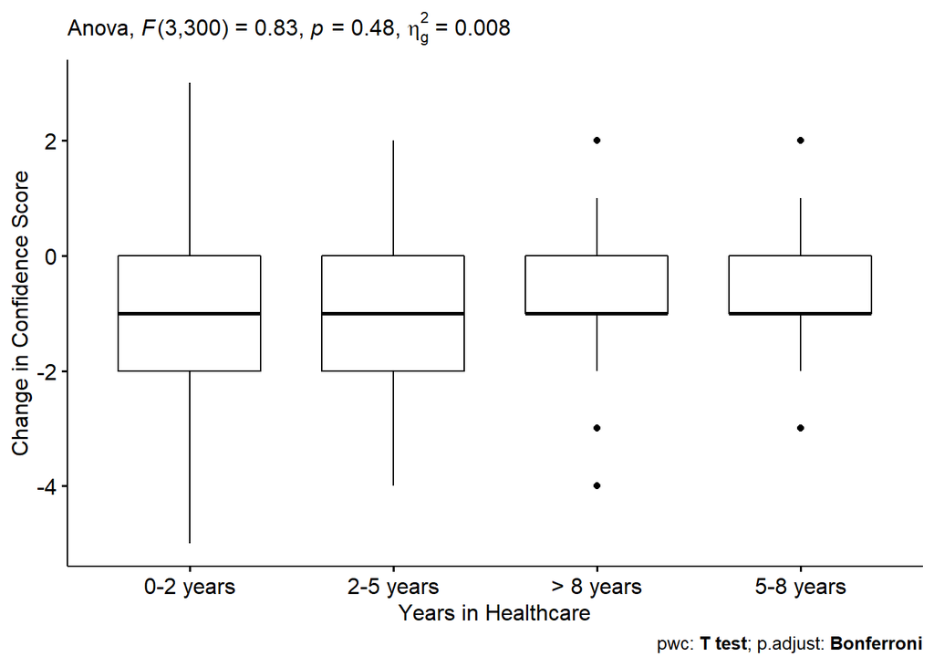

```r
#show significant levels
#hide non-significant tests

pwc_healthcare_plot <- ggpubr::ggboxplot(data_pairwise, x = "HealthcareYears", y = "delta") +
                       ggpubr::stat_pvalue_manual(pwchealthcare,
                                                  hide.ns = TRUE,
                                                  label = "p.adj",
                                                  y.position = 0.15,
                                                  step.increase = 0.2) +
                             labs(x = "Years in Healthcare",
                                  y = "Change in Confidence Score",
                                  subtitle = rstatix::get_test_label(healthcareaov, detailed = TRUE),
                                  caption = rstatix::get_pwc_label(pwchealthcare))
pwc_healthcare_plot
```

```r
#save plot
pwchealthcare_plot = here::here("results", "prepost", "pwc_healthcare_plot.png")
ggsave(filename = pwchealthcare_plot,
       plot = pwc_facility_plot,
       dpi = 300)
```

### Facility-Years

This is continuous - so categorical tests won’t work. We’ll create a scatter plot and examine the correlation.

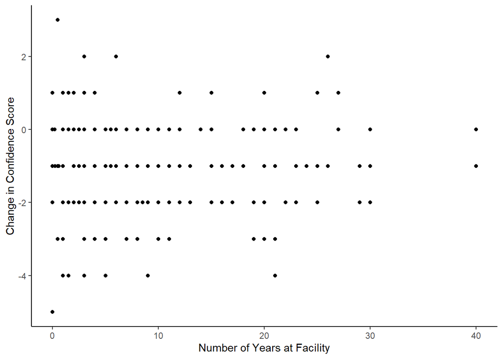

```r
facyrs_plot <- ggplot2::ggplot(data = data_pairwise, aes(x = FacilityYears, y = delta)) +
                          geom_point() +
                          labs(x = "Number of Years at Facility",
                               y = "Change in Confidence Score")
facyrs_plot
```

```r
facyrs_fit <- stats::lm(delta ~ FacilityYears, data = data_pairwise)

summary(facyrs_fit)
```

```
##
## Call:
## stats::lm(formula = delta ~ FacilityYears, data = data_pairwise)
##
## Residuals:
##     Min      1Q  Median      3Q     Max
## -4.0792 -1.0858 -0.0924  0.8878  3.9175
##
## Coefficients:
##                Estimate Std. Error t value            Pr(>|t|)
## (Intercept)   -0.920787   0.094059  -9.789 <0.0000000000000002 ***
## FacilityYears  0.006590   0.008331   0.791                0.43
## ---
## Signif. codes:  0 '***' 0.001 '**' 0.01 '*' 0.05 '.' 0.1 ' ' 1
##
## Residual standard error: 1.165 on 302 degrees of freedom
## Multiple R-squared:  0.002068,   Adjusted R-squared:  -0.001237
## F-statistic: 0.6257 on 1 and 302 DF,  p-value: 0.4296
```

```r
broom::tidy(facyrs_fit)
```

```
## # A tibble: 2 x 5
##   term          estimate std.error statistic  p.value
##   <chr>            <dbl>     <dbl>     <dbl>    <dbl>
## 1 (Intercept)   -0.921     0.0941     -9.79  7.81e-20
## 2 FacilityYears  0.00659   0.00833     0.791 4.30e- 1
```

Number of years at facility is not significant.

### Facilities-Number

This is continuous - so categorical tests won’t work. We’ll create a scatter plot and examine the correlation.

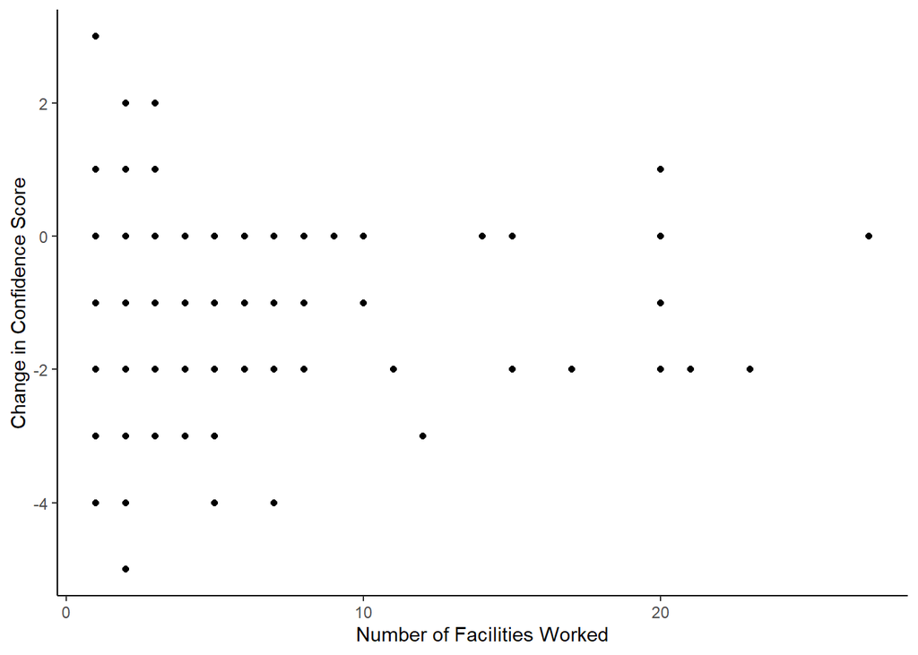

```r
facnum_plot <- ggplot2::ggplot(data = data_pairwise, aes(x = FacilitiesNumber, y = delta)) +
                          geom_point() +
                          labs(x = "Number of Facilities Worked",
                               y = "Change in Confidence Score")
facnum_plot
```

```r
facnum_fit <- stats::lm(delta ~ FacilitiesNumber, data = data_pairwise)

summary(facnum_fit)
```

```
##
## Call:
## stats::lm(formula = delta ~ FacilitiesNumber, data = data_pairwise)
##
## Residuals:
##     Min      1Q  Median      3Q     Max
## -4.1467 -1.0959 -0.1264  0.8533  3.8397
##
## Coefficients:
##                  Estimate Std. Error t value            Pr(>|t|)
## (Intercept)      -0.82619    0.08667  -9.532 <0.0000000000000002 ***
## FacilitiesNumber -0.01356    0.01772  -0.765               0.445
## ---
## Signif. codes:  0 '***' 0.001 '**' 0.01 '*' 0.05 '.' 0.1 ' ' 1
##
## Residual standard error: 1.165 on 302 degrees of freedom
## Multiple R-squared:  0.001934,   Adjusted R-squared:  -0.001371
## F-statistic: 0.5853 on 1 and 302 DF,  p-value: 0.4448
```

```r
broom::tidy(facnum_fit)
```

```
## # A tibble: 2 x 5
##   term             estimate std.error statistic  p.value
##   <chr>               <dbl>     <dbl>     <dbl>    <dbl>
## 1 (Intercept)       -0.826     0.0867    -9.53  5.32e-19
## 2 FacilitiesNumber  -0.0136    0.0177    -0.765 4.45e- 1
```

## Number of facilities worked is not significant.

### Shift-Type

1. Density plot of pre- and post-survey confidence scores

```r
#make a df for mean scores by shift type
data_long_shift <- data_1_long %>%
                        dplyr::group_by(TestCat, `Shift-Type`) %>%
                        dplyr::summarise(Mean.score = mean(score))
```

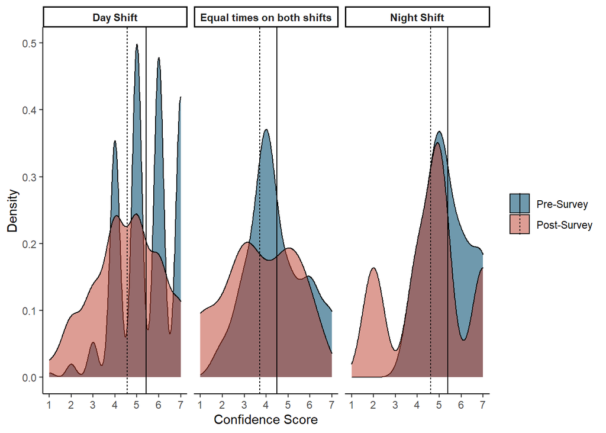

```r
#add a facet wrap to base plot for shift and lines for mean scores
#linetype for the mean confidence score varies by pre/post survey
shift_plot <- base_plot + ggplot2::facet_wrap(. ~ `Shift-Type`) +
                                   theme(strip.text.x = element_text(face = "bold")) +
                                   geom_vline(data = data_long_shift,
                                              mapping = aes(xintercept = Mean.score,
                                                            linetype = TestCat))

shift_plot
```

```r
#save plot
shift_conf_plot = here::here("results", "prepost", "shift_conf_plot.png")
ggsave(filename = shift_conf_plot,
       plot = shift_plot,
       width = 8, height = 5, dpi = 300)
```

2. Pairwise T-test by Shift Type

```r
#summary statistics
shift_sum_stats <- data_pairwise %>%
                        dplyr::group_by(ShiftType) %>%
                        rstatix::get_summary_stats(delta, type = "mean_sd")
shift_sum_stats
```

```
## # A tibble: 3 x 5
##   ShiftType                  variable     n   mean    sd
##   <chr>                      <chr>    <dbl>  <dbl> <dbl>
## 1 Day Shift                  delta      279 -0.875 1.14
## 2 Equal times on both shifts delta       20 -0.8   1.54
## 3 Night Shift                delta        5 -0.8   0.837
```

```r
#compare mean of shift type using ANOVA
shiftaov <- data_pairwise %>% rstatix::anova_test(delta ~ ShiftType)
```

```
## Coefficient covariances computed by hccm()
```

```r
shiftaov
```

```
## ANOVA Table (type II tests)
##
##      Effect DFn DFd     F     p p<.05     ges
## 1 ShiftType   2 301 0.047 0.954       0.00031
```

```r
#pairwise comparison by shift
pwcshift <- data_pairwise %>%
                  rstatix::pairwise_t_test(delta ~ ShiftType, p.adjust.method = "bonferroni")
pwcshift
```

```
## # A tibble: 3 x 9
##   .y.   group1              group2    n1    n2     p p.signif p.adj p.adj.signif
## * <chr> <chr>               <chr>  <int> <int> <dbl> <chr>    <dbl> <chr>
## 1 delta Day Shift           Equal~   279    20 0.783 ns           1 ns
## 2 delta Day Shift           Night~   279     5 0.888 ns           1 ns
## 3 delta Equal times on bot~ Night~    20     5 1     ns           1 ns
```

Shift Type is not significant.

3. Visualization: Box Plot with P-values

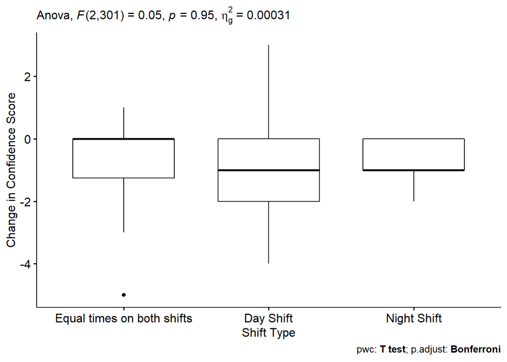

```r
#show significant levels
#hide non-significant tests

pwc_shift_plot <- ggpubr::ggboxplot(data_pairwise, x = "ShiftType", y = "delta") +
                     ggpubr::stat_pvalue_manual(pwcshift,
                                                hide.ns = TRUE,
                                                label = "p.adj",
                                                y.position = 0.15,
                                                step.increase = 0.2) +
                             labs(x = "Shift Type",
                                  y = "Change in Confidence Score",
                                  subtitle = rstatix::get_test_label(shiftaov, detailed = TRUE),
                                  caption = rstatix::get_pwc_label(pwcshift))
pwc_shift_plot
```

```r
#save plot
pwcshift_plot = here::here("results", "prepost", "pwc_shift_plot.png")

ggsave(filename = pwcshift_plot,
       plot = pwc_shift_plot,
       dpi = 300)
```

### EC-YN

1. Density plot of pre- and post-survey confidence scores

```r
#make a df for mean scores by EC knowledge
data_long_ec <- data_1_long %>%
                        dplyr::group_by(TestCat, `EC-YN`) %>%
                        dplyr::summarise(Mean.score = mean(score))
```

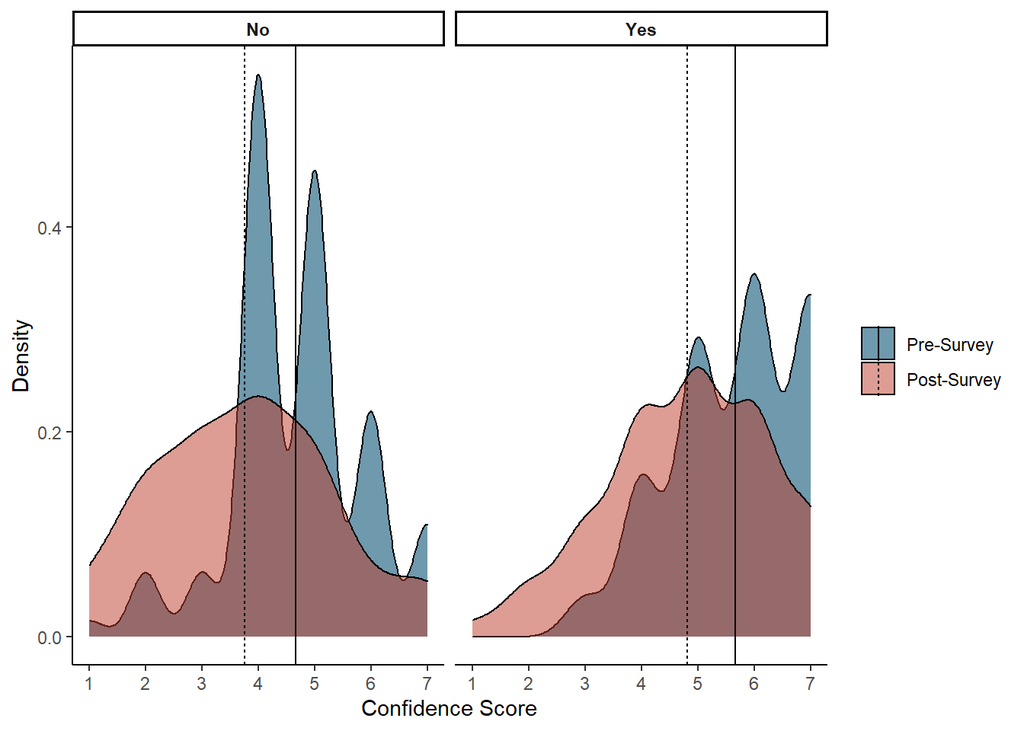

```r
#add a facet wrap to base plot for EC and lines for mean scores
#linetype for the mean confidence score varies by pre/post survey
EC_plot <- base_plot + ggplot2::facet_wrap(. ~ `EC-YN`) +
                                theme(strip.text.x = element_text(face = "bold")) +
                                geom_vline(data = data_long_ec,
                                           mapping = aes(xintercept = Mean.score,
                                                         linetype = TestCat))

EC_plot
```

```r
#save plot
ec_conf_plot = here::here("results", "prepost", "ec_conf_plot.png")
ggsave(filename = ec_conf_plot,
       plot = EC_plot,
       dpi = 300)
```

```r
#summary statistics
ec_sum_stats <- data_pairwise %>%
                        dplyr::group_by(ECYN) %>%
                        rstatix::get_summary_stats(delta, type = "mean_sd")
ec_sum_stats
```

```
## # A tibble: 2 x 5
##   ECYN  variable     n   mean    sd
##   <chr> <chr>    <dbl>  <dbl> <dbl>
## 1 No    delta       94 -0.904  1.30
## 2 Yes   delta      210 -0.852  1.10
```

```r
#compare mean of shift type using ANOVA
ecaov <- data_pairwise %>% rstatix::anova_test(delta ~ ECYN)
```

```
## Coefficient covariances computed by hccm()
```

```r
ecaov
```

```
## ANOVA Table (type II tests)
##
##   Effect DFn DFd     F    p p<.05      ges
## 1   ECYN   1 302 0.129 0.72       0.000425
```

```r
#pairwise comparison by shift
pwcec <- data_pairwise %>%
                  rstatix::pairwise_t_test(delta ~ ECYN, p.adjust.method = "bonferroni")
pwcec
```

```
## # A tibble: 1 x 9
##   .y.   group1 group2    n1    n2     p p.signif p.adj p.adj.signif
## * <chr> <chr>  <chr>  <int> <int> <dbl> <chr>    <dbl> <chr>
## 1 delta No     Yes       94   210  0.72 ns        0.72 ns
```

Knowledge of procedure for activating emergency codes is not significant.

3. Visualization: Box Plot with P-values

[figure not shown]

```r
#show significant levels
#hide non-significant tests

pwc_ec_plot <- ggpubr::ggboxplot(data_pairwise, x = "ECYN", y = "delta") +
                       ggpubr::stat_pvalue_manual(pwcec,
                                                hide.ns = TRUE,
                                                label = "p.adj",
                                                y.position = 0.15,
                                                step.increase = 0.2) +
                             labs(x = "Knowledge of Activation Procedure for Codes",
                                  y = "Change in Confidence Score",
                                  subtitle = rstatix::get_test_label(shiftaov, detailed = TRUE),
                                  caption = rstatix::get_pwc_label(pwcshift))
pwc_ec_plot
```

```r
#save plot
pwcec_plot = here::here("results", "prepost", "pwc_ec_plot.png")

ggsave(filename = pwcec_plot,
       plot = pwc_ec_plot,
       dpi = 300)
```

### Facilities-different-codes

1. Density plot of pre- and post-survey confidence scores

```r
#make a df for mean scores by different facility codes
data_long_facdiff <- data_1_long %>%
                        dplyr::group_by(TestCat, `Facilities-different-codes`) %>%
                        dplyr::summarise(Mean.score = mean(score))
```

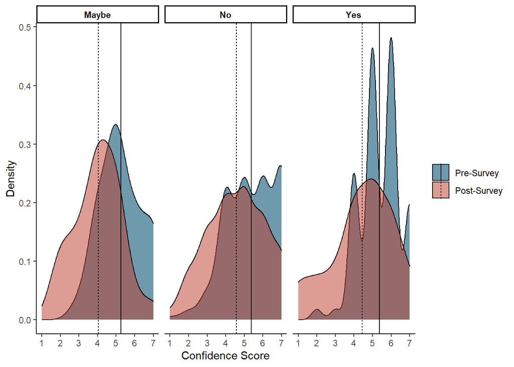

```r
#add a facet wrap to base plot for different facility codes and lines for mean scores
#linetype for the mean confidence score varies by pre/post survey
facdiff_plot <- base_plot + ggplot2::facet_wrap(. ~ `Facilities-different-codes`) +
                                     theme(strip.text.x = element_text(face = "bold")) +
                                     geom_vline(data = data_long_facdiff,
                                                mapping = aes(xintercept = Mean.score,
                                                              linetype = TestCat))

facdiff_plot
```

```r
#save plot
facdiff_conf_plot = here::here("results", "prepost", "facdiff_conf_plot.png")
ggsave(filename = facdiff_conf_plot,
       plot = facdiff_plot,
       dpi = 300)
```

2. Pairwise T-test by Facilities wit Different Codes

```r
#summary statistics
facdiff_sum_stats <- data_pairwise %>%
                        dplyr::group_by(Facilitiesdifferentcodes) %>%
                        rstatix::get_summary_stats(delta, type = "mean_sd")
facdiff_sum_stats
```

```
## # A tibble: 3 x 5
##   Facilitiesdifferentcodes variable     n   mean    sd
##   <chr>                    <chr>    <dbl>  <dbl> <dbl>
## 1 Maybe                    delta       27 -1.22   1.09
## 2 No                       delta      197 -0.797  1.12
## 3 Yes                      delta       80 -0.925  1.27
```

```r
#compare mean of facdiff using ANOVA
facdiffaov <- data_pairwise %>% rstatix::anova_test(delta ~ Facilitiesdifferentcodes)
```

```
## Coefficient covariances computed by hccm()
```

```r
facdiffaov
```

```
## ANOVA Table (type II tests)
##
##                     Effect DFn DFd    F     p p<.05   ges
## 1 Facilitiesdifferentcodes   2 301 1.72 0.181       0.011
```

```r
#pairwise comparison by facdiff
pwcfacdiff <- data_pairwise %>%
                  rstatix::pairwise_t_test(delta ~ Facilitiesdifferentcodes, p.adjust.method = "bonferroni")
pwcfacdiff
```

```
## # A tibble: 3 x 9
##   .y.   group1 group2    n1    n2      p p.signif p.adj p.adj.signif
## * <chr> <chr>  <chr>  <int> <int>  <dbl> <chr>    <dbl> <chr>
## 1 delta Maybe  No        27   197 0.0754 ns       0.226 ns
## 2 delta Maybe  Yes       27    80 0.251  ns       0.754 ns
## 3 delta No     Yes      197    80 0.406  ns       1     ns
```

Whether they have worked at a facility with different codes is not significant.

3. Visualization: Box Plot with P-values

[figure not shown]

```r
#show significant levels
#hide non-significant tests

pwc_facdiff_plot <- ggpubr::ggboxplot(data_pairwise, x = "Facilitiesdifferentcodes", y = "delta") +
                     ggpubr::stat_pvalue_manual(pwcfacdiff,
                                                hide.ns = TRUE,
                                                label = "p.adj",
                                                y.position = 0.15,
                                                step.increase = 0.2) +
                             labs(x = "Worked at a Facility with Different Color Codes",
                                  y = "Change in Confidence Score",
                                  subtitle = rstatix::get_test_label(shiftaov, detailed = TRUE),
                                  caption = rstatix::get_pwc_label(pwcshift))
pwc_facdiff_plot
```

```r
#save plot
pwcfacdiff_plot = here::here("results", "prepost", "pwc_facdiff_plot.png")

ggsave(filename = pwcfacdiff_plot,
       plot = pwc_facdiff_plot,
       dpi = 300)
```

## Scores by Code Opinions

We want to know if the distribution of confidence scores varies by opinions on color codes. The following variables will be analyzed:

- PL-codes
- Code-exceptions
- Training-Orientation
- Training-Yearly
- Training-Exercise
- Training-OtherCat
- Training-last-time
- Code-confusion

The following steps will be followed for each variable:

1. Visualization: Pre/Post Density Plot
2. Pairwise t-test (with a bonferroni correction)
3. Visualization: Box Plot with p-values

The density plot visualization will just build off of the `base_plot` developed above.

### PL-codes

1. Density plot of pre- and post-survey confidence scores

```r
#make a df for mean scores by pl code preference
data_long_plcodes <- data_1_long %>%
                        dplyr::group_by(TestCat, `PL-codes`) %>%
                        dplyr::summarise(Mean.score = mean(score))
```

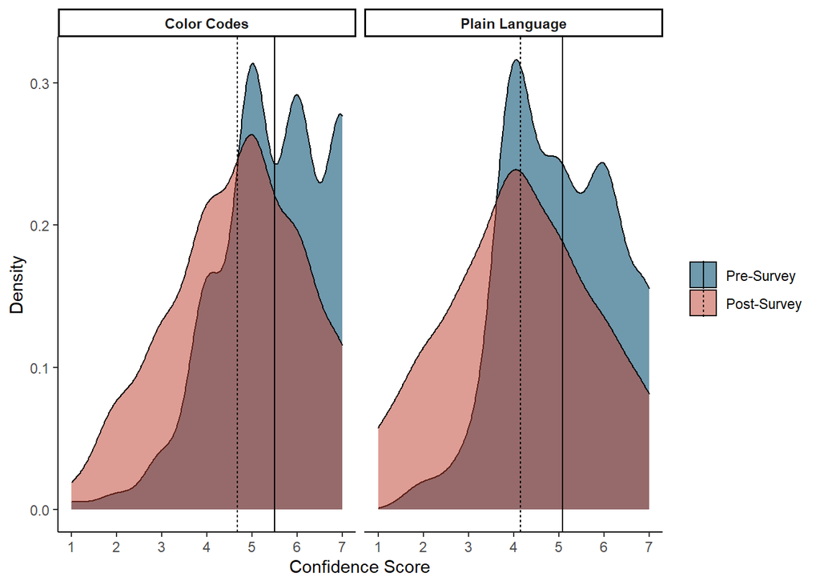

```r
#add a facet wrap to base plot for pl codes and lines for mean scores
#linetype for the mean confidence score varies by pre/post survey
plcodes_plot <- base_plot + ggplot2::facet_wrap(. ~ `PL-codes`) +
                                      theme(strip.text.x = element_text(face = "bold")) +
                                      geom_vline(data = data_long_plcodes,
                                                 mapping = aes(xintercept = Mean.score,
                                                               linetype = TestCat))

plcodes_plot
```

```r
#save plot
plcodes_conf_plot = here::here("results", "prepost", "plcodes_conf_plot.png")
ggsave(filename = plcodes_conf_plot,
       plot = plcodes_plot,
       dpi = 300)
```

2. Pairwise T-test by code preference

```r
#summary statistics
plcodes_sum_stats <- data_pairwise %>%
                        dplyr::group_by(PLcodes) %>%
                        rstatix::get_summary_stats(delta, type = "mean_sd")
plcodes_sum_stats
```

```
## # A tibble: 2 x 5
##   PLcodes        variable     n   mean    sd
##   <chr>          <chr>    <dbl>  <dbl> <dbl>
## 1 Color Codes    delta      199 -0.834  1.14
## 2 Plain Language delta      105 -0.933  1.21
```

```r
#compare mean of code preference using ANOVA
plcodesaov <- data_pairwise %>% rstatix::anova_test(delta ~ PLcodes)
```

```
## Coefficient covariances computed by hccm()
```

```r
plcodesaov
```

```
## ANOVA Table (type II tests)
##
##    Effect DFn DFd     F     p p<.05   ges
## 1 PLcodes   1 302 0.498 0.481       0.002
```

```r
#pairwise comparison by code preference
pwcplcodes <- data_pairwise %>%
                  rstatix::pairwise_t_test(delta ~ PLcodes, p.adjust.method = "bonferroni")
pwcplcodes
```

```
## # A tibble: 1 x 9
##   .y.   group1      group2            n1    n2     p p.signif p.adj p.adj.signif
## * <chr> <chr>       <chr>          <int> <int> <dbl> <chr>    <dbl> <chr>
## 1 delta Color Codes Plain Language   199   105 0.481 ns       0.481 ns
```

Code preference is not significant.

3. Visualization: Box Plot with P-values

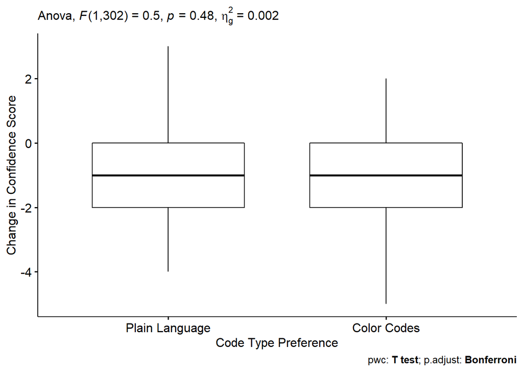

```r
#show significant levels
#hide non-significant tests

pwc_plcodes_plot <- ggpubr::ggboxplot(data_pairwise, x = "PLcodes", y = "delta") +
                     ggpubr::stat_pvalue_manual(pwcplcodes,
                                                hide.ns = TRUE,
                                                label = "p.adj",
                                                y.position = 0.15,
                                                step.increase = 0.2) +
                             labs(x = "Code Type Preference",
                                  y = "Change in Confidence Score",
                                  subtitle = rstatix::get_test_label(plcodesaov, detailed = TRUE),
                                  caption = rstatix::get_pwc_label(pwcplcodes))
pwc_plcodes_plot
```

```r
#save plot
pwcplcodes_plot = here::here("results", "prepost", "pwc_plcodes_plot.png")
ggsave(filename = pwcplcodes_plot,
       plot = pwc_plcodes_plot,
       dpi = 300)
```

### Code-exceptions

1. Density plot of pre- and post-survey confidence scores

```r
#make a df for mean scores by code exceptions
data_long_excepts <- data_1_long %>%
                        dplyr::group_by(TestCat, `Code-exceptions`) %>%
                        dplyr::summarise(Mean.score = mean(score))
```

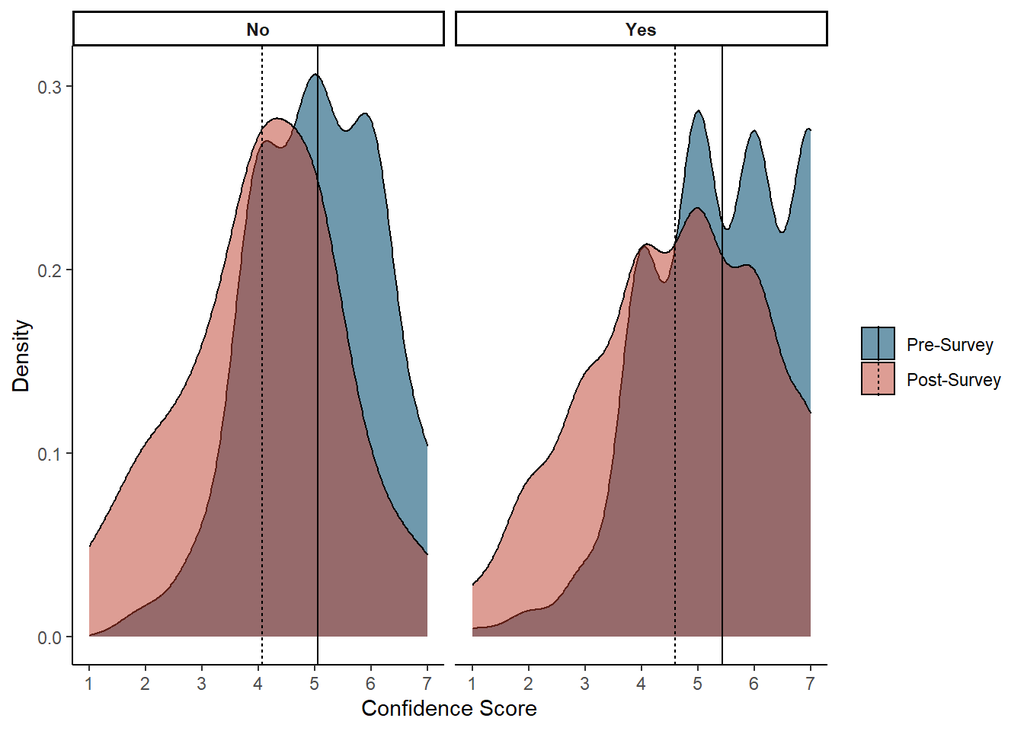

```r
#add a facet wrap to base plot for exceptions and lines for mean scores
#linetype for the mean confidence score varies by pre/post survey
excepts_plot <- base_plot + ggplot2::facet_wrap(. ~ `Code-exceptions`) +
                                      theme(strip.text.x = element_text(face = "bold")) +
                                      geom_vline(data = data_long_excepts,
                                                 mapping = aes(xintercept = Mean.score,
                                                               linetype = TestCat))

excepts_plot
```

```r
#save plot
excepts_conf_plot = here::here("results", "prepost", "excepts_conf_plot.png")
ggsave(filename = excepts_conf_plot,
       plot = excepts_plot,
       dpi = 300)
```

2. Pairwise T-test by code exceptions

```r
#summary statistics
excepts_sum_stats <- data_pairwise %>%
                        dplyr::group_by(Codeexceptions) %>%
                        rstatix::get_summary_stats(delta, type = "mean_sd")
excepts_sum_stats
```

```
## # A tibble: 2 x 5
##   Codeexceptions variable     n   mean    sd
##   <chr>          <chr>    <dbl>  <dbl> <dbl>
## 1 No             delta       64 -0.984  1.40
## 2 Yes            delta      240 -0.838  1.10
```

```r
#compare mean of code exceptions using ANOVA
exceptsaov <- data_pairwise %>% rstatix::anova_test(delta ~ Codeexceptions)
```

```
## Coefficient covariances computed by hccm()
```

```r
exceptsaov
```

```
## ANOVA Table (type II tests)
##
##           Effect DFn DFd     F     p p<.05   ges
## 1 Codeexceptions   1 302 0.804 0.371       0.003
```

```r
#pairwise comparison by code exceptions
pwcexcepts <- data_pairwise %>%
                  rstatix::pairwise_t_test(delta ~ Codeexceptions, p.adjust.method = "bonferroni")
pwcexcepts
```

```
## # A tibble: 1 x 9
##   .y.   group1 group2    n1    n2     p p.signif p.adj p.adj.signif
## * <chr> <chr>  <chr>  <int> <int> <dbl> <chr>    <dbl> <chr>
## 1 delta No     Yes       64   240 0.371 ns       0.371 ns
```

Preference to keep certain exceptions for plain language code is not significant.

3. Visualization: Box Plot with P-values

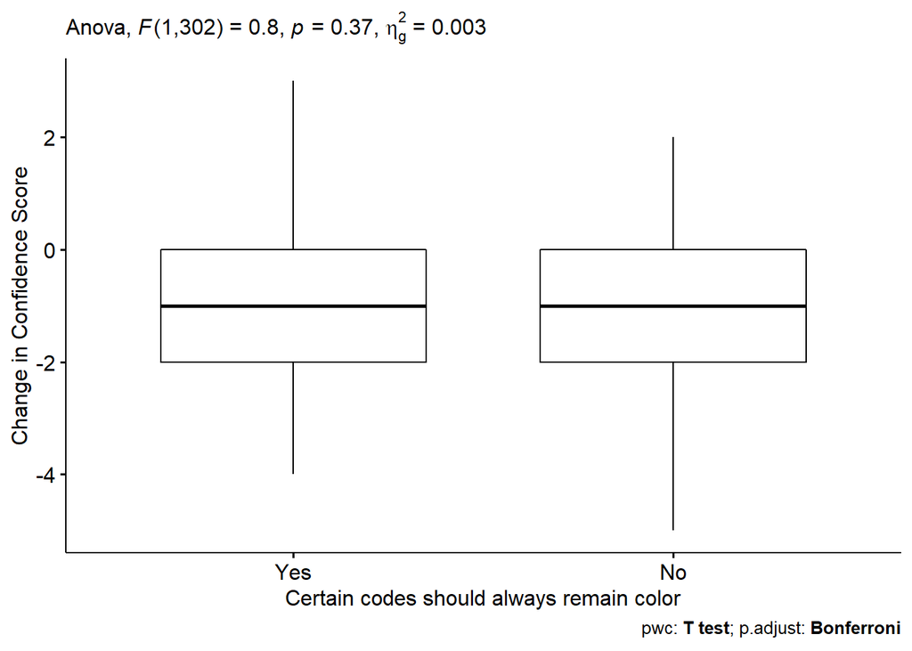

```r
#show significant levels
#hide non-significant tests

pwc_excepts_plot <- ggpubr::ggboxplot(data_pairwise, x = "Codeexceptions", y = "delta") +
                     ggpubr::stat_pvalue_manual(pwcexcepts,
                                                hide.ns = TRUE,
                                                label = "p.adj",
                                                y.position = 0.15,
                                                step.increase = 0.2) +
                             labs(x = "Certain codes should always remain color",
                                  y = "Change in Confidence Score",
                                  subtitle = rstatix::get_test_label(exceptsaov, detailed = TRUE),
                                  caption = rstatix::get_pwc_label(pwcexcepts))
pwc_excepts_plot
```

```r
#save plot
pwcexcepts_plot = here::here("results", "prepost", "pwc_excepts_plot.png")
ggsave(filename = pwcexcepts_plot,
       plot = pwc_excepts_plot,
       dpi = 300)
```

### Training-Orientation

1. Density plot of pre- and post-survey confidence scores

```r
#make a df for mean scores by code exceptions
data_long_orientation <- data_1_long %>%
                             dplyr::group_by(TestCat, `Training-Orientation`) %>%
                             dplyr::summarise(Mean.score = mean(score))
```

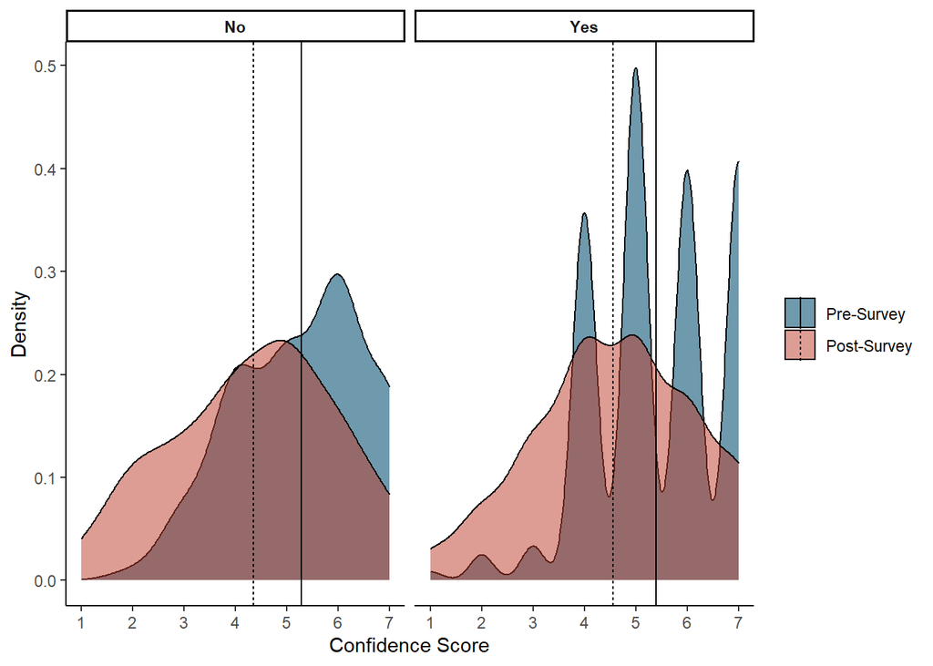

```r
#add a facet wrap to base plot for training at orientation and lines for mean scores
#linetype for the mean confidence score varies by pre/post survey
orientation_plot <- base_plot + ggplot2::facet_wrap(. ~ `Training-Orientation`) +
                                         theme(strip.text.x = element_text(face = "bold")) +
                                         geom_vline(data = data_long_orientation,
                                                    mapping = aes(xintercept = Mean.score,
                                                                  linetype = TestCat))

orientation_plot
```

```r
#save plot
orientation_conf_plot = here::here("results", "prepost", "orientation_conf_plot.png")
ggsave(filename = orientation_conf_plot,
       plot = orientation_plot,
       dpi = 300)
```

2. Pairwise T-test by training at orientation

```r
#summary statistics
orientation_sum_stats <- data_pairwise %>%
                           dplyr::group_by(TrainingOrientation) %>%
                           rstatix::get_summary_stats(delta, type = "mean_sd")
orientation_sum_stats
```

```
## # A tibble: 2 x 5
##   TrainingOrientation variable     n   mean    sd
##   <chr>               <chr>    <dbl>  <dbl> <dbl>
## 1 No                  delta       96 -0.938  1.19
## 2 Yes                 delta      208 -0.837  1.16
```

```r
#compare mean of training at orientation using ANOVA
orientationaov <- data_pairwise %>% rstatix::anova_test(delta ~ TrainingOrientation)
```

```
## Coefficient covariances computed by hccm()
```

```r
orientationaov
```

```
## ANOVA Table (type II tests)
##
##                Effect DFn DFd     F     p p<.05   ges
## 1 TrainingOrientation   1 302 0.493 0.483       0.002
```

```r
#pairwise comparison by training at orientation
pwcorientation <- data_pairwise %>%
                         rstatix::pairwise_t_test(delta ~ TrainingOrientation, p.adjust.method = "bonferroni")
pwcorientation
```

```
## # A tibble: 1 x 9
##   .y.   group1 group2    n1    n2     p p.signif p.adj p.adj.signif
## * <chr> <chr>  <chr>  <int> <int> <dbl> <chr>    <dbl> <chr>
## 1 delta No     Yes       96   208 0.483 ns       0.483 ns
```

Training at Orientation is not significant.

3. Visualization: Box Plot with P-values

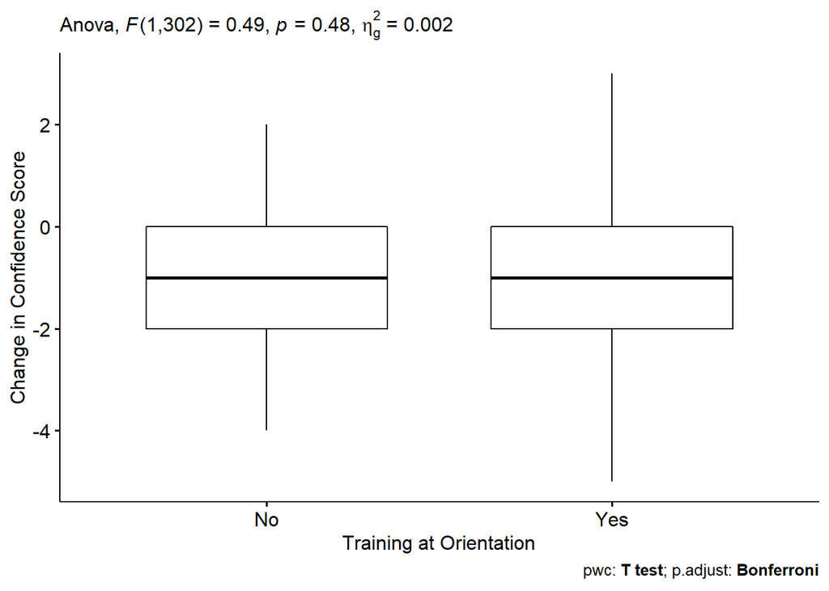

```r
#show significant levels
#hide non-significant tests

pwc_orientation_plot <- ggpubr::ggboxplot(data_pairwise, x = "TrainingOrientation", y = "delta") +
                         ggpubr::stat_pvalue_manual(pwcorientation,
                                                    hide.ns = TRUE,
                                                    label = "p.adj",
                                                    y.position = 0.15,
                                                    step.increase = 0.2) +
                                 labs(x = "Training at Orientation",
                                      y = "Change in Confidence Score",
                                      subtitle = rstatix::get_test_label(orientationaov, detailed = TRUE),
                                      caption = rstatix::get_pwc_label(pwcorientation))
pwc_orientation_plot
```

```r
#save plot
pwcorientation_plot = here::here("results", "prepost", "pwc_orientation_plot.png")
ggsave(filename = pwcorientation_plot,
       plot = pwc_orientation_plot,
       dpi = 300)
```

### Training-Yearly

1. Density plot of pre- and post-survey confidence scores

```r
#make a df for mean scores by code exceptions
data_long_yearly <- data_1_long %>%
                             dplyr::group_by(TestCat, `Training-Yearly`) %>%
                             dplyr::summarise(Mean.score = mean(score))
```

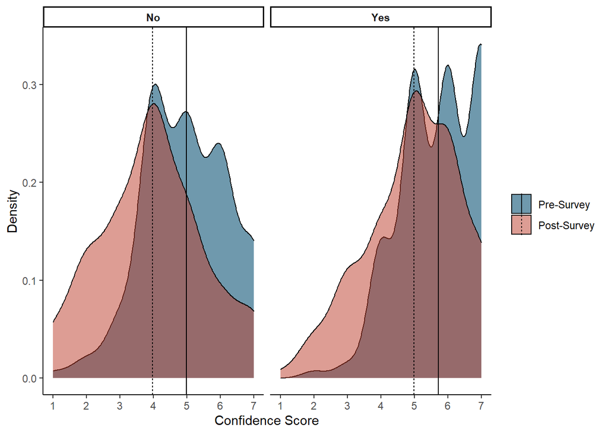

```r
#add a facet wrap to base plot for yearly training and lines for mean scores
#linetype for the mean confidence score varies by pre/post survey
yearly_plot <- base_plot + ggplot2::facet_wrap(. ~ `Training-Yearly`) +
                                         theme(strip.text.x = element_text(face = "bold")) +
                                         geom_vline(data = data_long_yearly,
                                                    mapping = aes(xintercept = Mean.score,
                                                                  linetype = TestCat))

yearly_plot
```

```r
#save plot
yearly_conf_plot = here::here("results", "prepost", "yearly_conf_plot.png")
ggsave(filename = yearly_conf_plot,
       plot = yearly_plot,
       dpi = 300)
```

2. Pairwise T-test by yearly training

```r
#summary statistics
yearly_sum_stats <- data_pairwise %>%
                           dplyr::group_by(TrainingYearly) %>%
                           rstatix::get_summary_stats(delta, type = "mean_sd")
yearly_sum_stats
```

```
## # A tibble: 2 x 5
##   TrainingYearly variable     n   mean    sd
##   <chr>          <chr>    <dbl>  <dbl> <dbl>
## 1 No             delta      149 -1.01   1.23
## 2 Yes            delta      155 -0.729  1.08
```

```r
#compare mean of yearly training using ANOVA
yearlyaov <- data_pairwise %>% rstatix::anova_test(delta ~ TrainingYearly)
```

```
## Coefficient covariances computed by hccm()
```

```r
yearlyaov
```

```
## ANOVA Table (type II tests)
##
##           Effect DFn DFd     F     p p<.05   ges
## 1 TrainingYearly   1 302 4.586 0.033     * 0.015
```

```r
#pairwise comparison by yearly training
pwcyearly <- data_pairwise %>%
                    rstatix::pairwise_t_test(delta ~ TrainingYearly, p.adjust.method = "bonferroni")
pwcyearly
```

```
## # A tibble: 1 x 9
##   .y.   group1 group2    n1    n2     p p.signif p.adj p.adj.signif
## * <chr> <chr>  <chr>  <int> <int> <dbl> <chr>    <dbl> <chr>
## 1 delta No     Yes      149   155 0.033 *        0.033 *
```

Yearly training is significant.

3. Visualization: Box Plot with P-values

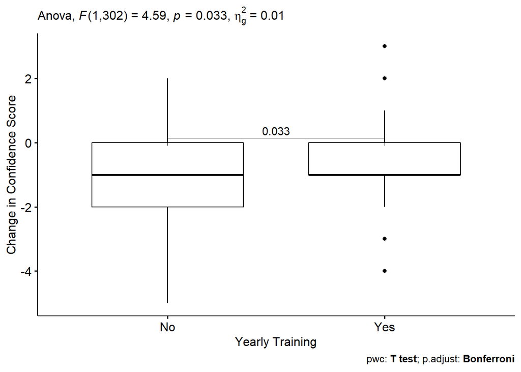

```r
#show significant levels
#hide non-significant tests

pwc_yearly_plot <- ggpubr::ggboxplot(data_pairwise, x = "TrainingYearly", y = "delta") +
                         ggpubr::stat_pvalue_manual(pwcyearly,
                                                    hide.ns = TRUE,
                                                    label = "p.adj",
                                                    y.position = 0.15,
                                                    step.increase = 0.2) +
                                 labs(x = "Yearly Training",
                                      y = "Change in Confidence Score",
                                      subtitle = rstatix::get_test_label(yearlyaov, detailed = TRUE),
                                      caption = rstatix::get_pwc_label(pwcyearly))
pwc_yearly_plot
```

```r
#save plot
pwcyearly_plot = here::here("results", "prepost", "pwc_yearly_plot.png")
ggsave(filename = pwcyearly_plot,
       plot = pwc_yearly_plot,
       dpi = 300)
```

### Training-Exercises

1. Density plot of pre- and post-survey confidence scores

```r
#make a df for mean scores by training during drills and exercises
data_long_exercises <- data_1_long %>%
                             dplyr::group_by(TestCat, `Training-Exercises`) %>%
                             dplyr::summarise(Mean.score = mean(score))
```

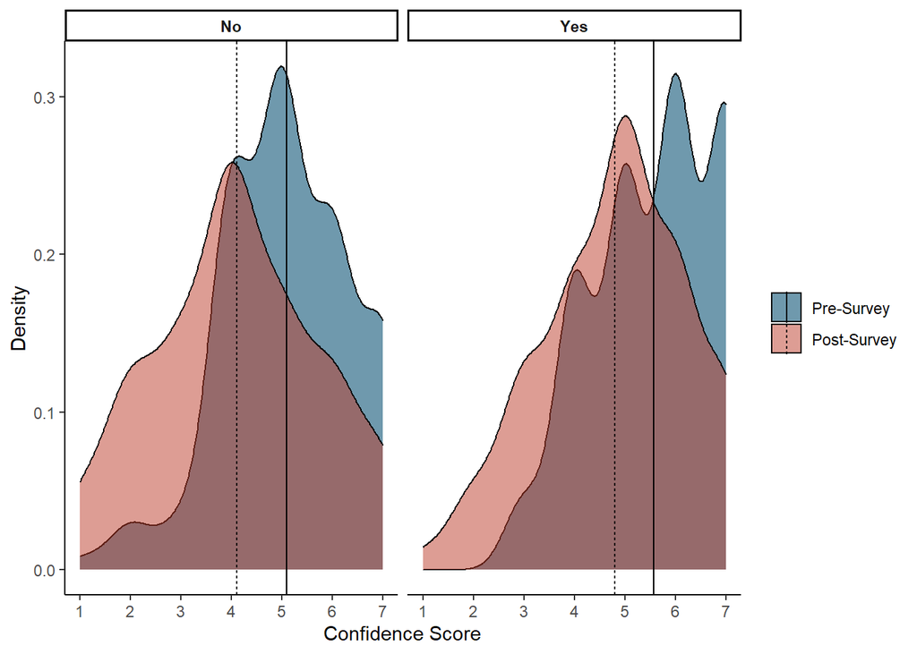

```r
#add a facet wrap to base plot for training at exercises and lines for mean scores
#linetype for the mean confidence score varies by pre/post survey
exercises_plot <- base_plot + ggplot2::facet_wrap(. ~ `Training-Exercises`) +
                                       theme(strip.text.x = element_text(face = "bold")) +
                                       geom_vline(data = data_long_exercises,
                                                  mapping = aes(xintercept = Mean.score,
                                                                linetype = TestCat))

exercises_plot
```

```r
#save plot
exercises_conf_plot = here::here("results", "prepost", "exercises_conf_plot.png")
ggsave(filename = exercises_conf_plot,
       plot = exercises_plot,
       dpi = 300)
```

2. Pairwise T-test by training at exercises

```r
#summary statistics
exercises_sum_stats <- data_pairwise %>%
                           dplyr::group_by(TrainingExercises) %>%
                           rstatix::get_summary_stats(delta, type = "mean_sd")
exercises_sum_stats
```

```
## # A tibble: 2 x 5
##   TrainingExercises variable     n   mean    sd
##   <chr>             <chr>    <dbl>  <dbl> <dbl>
## 1 No                delta      135 -0.985  1.23
## 2 Yes               delta      169 -0.775  1.1
```

```r
#compare mean of training at exercises using ANOVA
exercisesaov <- data_pairwise %>% rstatix::anova_test(delta ~ TrainingExercises)
```

```
## Coefficient covariances computed by hccm()
```

```r
exercisesaov
```

```
## ANOVA Table (type II tests)
##
##              Effect DFn DFd     F     p p<.05   ges
## 1 TrainingExercises   1 302 2.454 0.118       0.008
```

```r
#pairwise comparison by training at exercises
pwcexercises <- data_pairwise %>%
                         rstatix::pairwise_t_test(delta ~ TrainingExercises, p.adjust.method = "bonferroni")
pwcexercises
```

```
## # A tibble: 1 x 9
##   .y.   group1 group2    n1    n2     p p.signif p.adj p.adj.signif
## * <chr> <chr>  <chr>  <int> <int> <dbl> <chr>    <dbl> <chr>
## 1 delta No     Yes      135   169 0.118 ns       0.118 ns
```

Training at Exercises is not significant.

3. Visualization: Box Plot with P-values

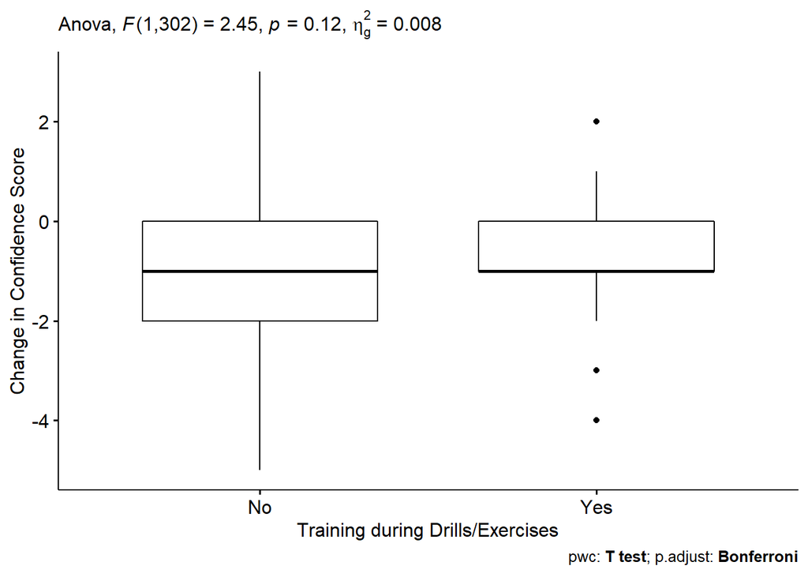

```r
#show significant levels
#hide non-significant tests

pwc_exercises_plot <- ggpubr::ggboxplot(data_pairwise, x = "TrainingExercises", y = "delta") +
                         ggpubr::stat_pvalue_manual(pwcexercises,
                                                    hide.ns = TRUE,
                                                    label = "p.adj",
                                                    y.position = 0.15,
                                                    step.increase = 0.2) +
                                 labs(x = "Training during Drills/Exercises",
                                      y = "Change in Confidence Score",
                                      subtitle = rstatix::get_test_label(exercisesaov, detailed = TRUE),
                                      caption = rstatix::get_pwc_label(pwcexercises))
pwc_exercises_plot
```

```r
#save plot
pwcexercises_plot = here::here("results", "prepost", "pwc_exercises_plot.png")
ggsave(filename = pwcexercises_plot,
       plot = pwc_exercises_plot,
       dpi = 300)
```

### Training-OtherCat

1. Density plot of pre- and post-survey confidence scores

```r
#make a df for mean scores by other training
data_long_OtherCat <- data_1_long %>%
                             dplyr::group_by(TestCat, `Training-OtherCat`) %>%
                             dplyr::summarise(Mean.score = mean(score))
```

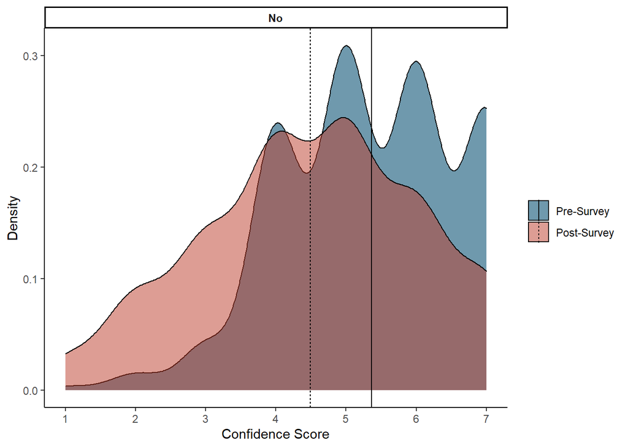

```r
#add a facet wrap to base plot for other training and lines for mean scores
#linetype for the mean confidence score varies by pre/post survey
OtherCat_plot <- base_plot + ggplot2::facet_wrap(. ~ `Training-OtherCat`) +
                                       theme(strip.text.x = element_text(face = "bold")) +
                                       geom_vline(data = data_long_OtherCat,
                                                  mapping = aes(xintercept = Mean.score,
                                                                linetype = TestCat))

OtherCat_plot
```

```r
#save plot
OtherCat_conf_plot = here::here("results", "prepost", "OtherCat_conf_plot.png")
ggsave(filename = OtherCat_conf_plot,
       plot = OtherCat_plot,
       dpi = 300)
```

No respondents provided another category of training.

### Training-last-time

1. Density plot of pre- and post-survey confidence scores

```r
#make a df for mean scores by years in last training
data_long_lasttrain <- data_1_long %>%
                        dplyr::group_by(TestCat, `Training-last-time`) %>%
                        dplyr::summarise(Mean.score = mean(score))
```

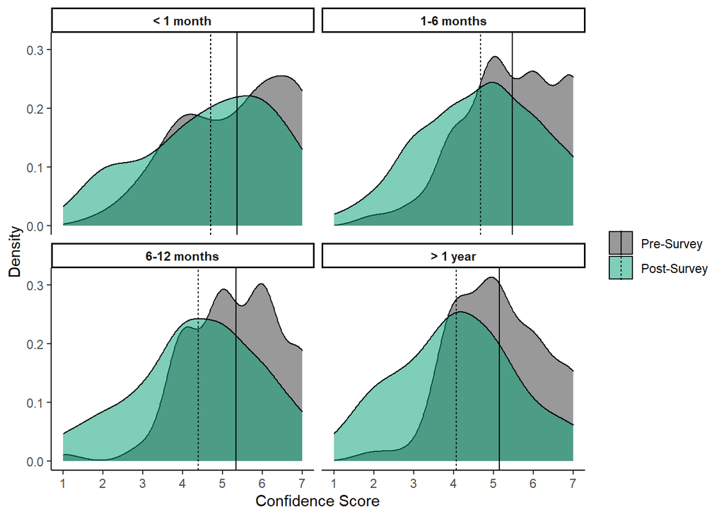

```r
#reorder the levels of lasttrain using relevel
#replicate data
data_1_long_lt <- data_1_long

#reorder group factor levels
data_1_long_lt$`Training-last-time` <- factor(data_1_long_lt$`Training-last-time`,
                                              levels = c("< 1 month", "1-6 months", "6-12 months", "> 1 year"))
data_long_lasttrain$`Training-last-time` <- factor(data_long_lasttrain$`Training-last-time`,
                                                  levels = c("< 1 month", "1-6 months", "6-12 months", "> 1 year"))


#we have to re-do the whole plot in order to reorder the lasttrain category
#linetype for the mean confidence score varies by pre/post survey
lasttrain_plot <- ggplot2::ggplot(data = data_1_long_lt, aes(x = score)) +
                            geom_density(aes(fill = TestCat,
                                             alpha = TestCat)) +
                            scale_fill_manual(values = c("#999999", "#009E73")) +
                            scale_alpha_manual(values = c(1, 0.5)) +
                            scale_x_continuous(breaks = seq(1, 7, by = 1)) +
                            facet_wrap(. ~ `Training-last-time`) +
                            geom_vline(data = data_long_lasttrain,
                                       mapping = aes(xintercept = Mean.score,
                                                     linetype = TestCat)) +
                            theme(legend.title = element_blank(),
                                  strip.text.x = element_text(face = "bold")) +
                            labs(y = "Density",
                                 x = "Confidence Score")
lasttrain_plot
```

```r
#save plot
lasttrain_conf_plot = here::here("results", "prepost", "lasttrain_conf_plot.png")
ggsave(filename = lasttrain_conf_plot,
       plot = lasttrain_plot,
       dpi = 300)
```

2. Pairwise T-test by lasttrain

```r
#summary statistics
lasttrain_sum_stats <- data_pairwise %>%
                        dplyr::group_by(Traininglasttime) %>%
                        rstatix::get_summary_stats(delta, type = "mean_sd")
lasttrain_sum_stats
```

```
## # A tibble: 4 x 5
##   Traininglasttime variable     n   mean    sd
##   <chr>            <chr>    <dbl>  <dbl> <dbl>
## 1 < 1 month        delta       51 -0.667  1.11
## 2 > 1 year         delta       57 -1.09   1.26
## 3 1-6 months       delta      113 -0.796  1.18
## 4 6-12 months      delta       83 -0.94   1.10
```

```r
#compare mean of lasttrain using ANOVA
lasttrainaov <- data_pairwise %>% rstatix::anova_test(delta ~ Traininglasttime)
```

```
## Coefficient covariances computed by hccm()
```

```r
lasttrainaov
```

```
## ANOVA Table (type II tests)
##
##             Effect DFn DFd     F     p p<.05   ges
## 1 Traininglasttime   3 300 1.439 0.232       0.014
```

```r
#pairwise comparison by lasttrain
pwclasttrain <- data_pairwise %>%
                  rstatix::pairwise_t_test(delta ~ Traininglasttime, p.adjust.method = "bonferroni")
pwclasttrain
```

```
## # A tibble: 6 x 9
##   .y.   group1     group2         n1    n2     p p.signif p.adj p.adj.signif
## * <chr> <chr>      <chr>       <int> <int> <dbl> <chr>    <dbl> <chr>
## 1 delta < 1 month  > 1 year       51    57 0.061 ns       0.366 ns
## 2 delta < 1 month  1-6 months     51   113 0.508 ns       1     ns
## 3 delta > 1 year   1-6 months     57   113 0.124 ns       0.743 ns
## 4 delta < 1 month  6-12 months    51    83 0.187 ns       1     ns
## 5 delta > 1 year   6-12 months    57    83 0.46  ns       1     ns
## 6 delta 1-6 months 6-12 months   113    83 0.394 ns       1     ns
```

Date of last training is not significant

3. Visualization: Box Plot with P-values

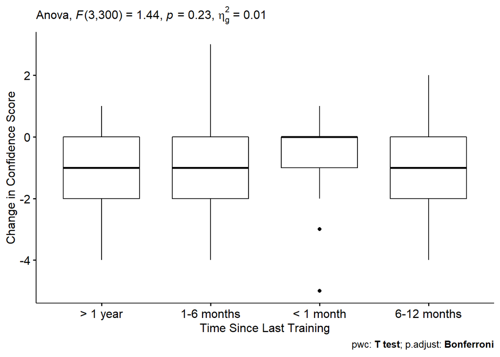

```r
#show significant levels
#hide non-significant tests

pwc_lasttrain_plot <- ggpubr::ggboxplot(data_pairwise, x = "Traininglasttime", y = "delta") +
                       ggpubr::stat_pvalue_manual(pwclasttrain,
                                                  hide.ns = TRUE,
                                                  label = "p.adj",
                                                  y.position = 0.15,
                                                  step.increase = 0.2) +
                               labs(x = "Time Since Last Training",
                                    y = "Change in Confidence Score",
                                    subtitle = rstatix::get_test_label(lasttrainaov, detailed = TRUE),
                                    caption = rstatix::get_pwc_label(pwclasttrain))
pwc_lasttrain_plot
```

```r
#save plot
pwclasttrain_plot = here::here("results", "prepost", "pwc_lasttrain_plot.png")
ggsave(filename = pwclasttrain_plot,
       plot = pwc_lasttrain_plot,
       dpi = 300)
```

### Code-confusion

1. Density plot of pre- and post-survey confidence scores

```r
#make a df for mean scores by witnessing code confusion
data_long_confusion <- data_1_long %>%
                             dplyr::group_by(TestCat, `Code-confusion`) %>%
                             dplyr::summarise(Mean.score = mean(score))
```

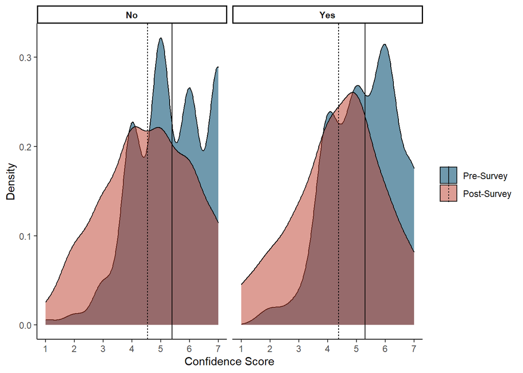

```r
#add a facet wrap to base plot for training at exercises and lines for mean scores
#linetype for the mean confidence score varies by pre/post survey
confusion_plot <- base_plot + ggplot2::facet_wrap(. ~ `Code-confusion`) +
                                       theme(strip.text.x = element_text(face = "bold")) +
                                       geom_vline(data = data_long_confusion,
                                                  mapping = aes(xintercept = Mean.score,
                                                                linetype = TestCat))

confusion_plot
```

```r
#save plot
confusion_conf_plot = here::here("results", "prepost", "confusion_conf_plot.png")
ggsave(filename = confusion_conf_plot,
       plot = confusion_plot,
       dpi = 300)
```

2. Pairwise T-test by code confusion

```r
#summary statistics
confusion_sum_stats <- data_pairwise %>%
                           dplyr::group_by(Codeconfusion) %>%
                           rstatix::get_summary_stats(delta, type = "mean_sd")
confusion_sum_stats
```

```
## # A tibble: 2 x 5
##   Codeconfusion variable     n   mean    sd
##   <chr>         <chr>    <dbl>  <dbl> <dbl>
## 1 No            delta      196 -0.847  1.10
## 2 Yes           delta      108 -0.907  1.28
```

```r
#compare mean of code confusion using ANOVA
confusionaov <- data_pairwise %>% rstatix::anova_test(delta ~ Codeconfusion)
```

```
## Coefficient covariances computed by hccm()
```

```r
confusionaov
```

```
## ANOVA Table (type II tests)
##
##          Effect DFn DFd     F     p p<.05     ges
## 1 Codeconfusion   1 302 0.187 0.665       0.00062
```

```r
#pairwise comparison by code confusion
pwcconfusion <- data_pairwise %>%
                         rstatix::pairwise_t_test(delta ~ Codeconfusion, p.adjust.method = "bonferroni")
pwcconfusion
```

```
## # A tibble: 1 x 9
##   .y.   group1 group2    n1    n2     p p.signif p.adj p.adj.signif
## * <chr> <chr>  <chr>  <int> <int> <dbl> <chr>    <dbl> <chr>
## 1 delta No     Yes      196   108 0.665 ns       0.665 ns
```

Witnessing code confusion is not significant.

3. Visualization: Box Plot with P-values

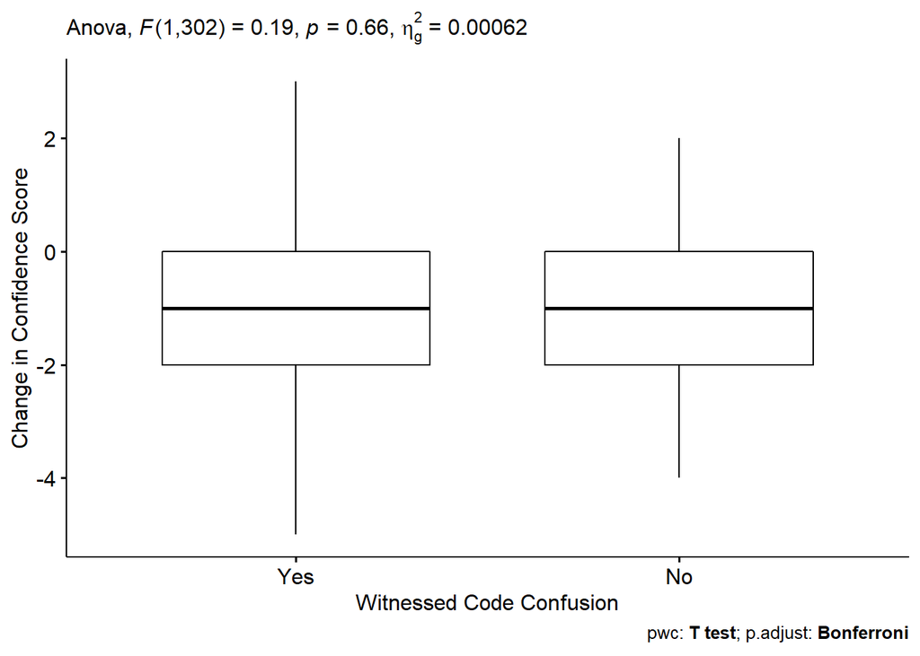

```r
#show significant levels
#hide non-significant tests

pwc_confusion_plot <- ggpubr::ggboxplot(data_pairwise, x = "Codeconfusion", y = "delta") +
                         ggpubr::stat_pvalue_manual(pwcconfusion,
                                                    hide.ns = TRUE,
                                                    label = "p.adj",
                                                    y.position = 0.15,
                                                    step.increase = 0.2) +
                                 labs(x = "Witnessed Code Confusion",
                                      y = "Change in Confidence Score",
                                      subtitle = rstatix::get_test_label(confusionaov, detailed = TRUE),
                                      caption = rstatix::get_pwc_label(pwcconfusion))
pwc_confusion_plot
```

```r
#save plot
pwcconfusion_plot = here::here("results", "prepost", "pwc_confusion_plot.png")
ggsave(filename = pwcconfusion_plot,
       plot = pwc_confusion_plot,
       dpi = 300)
```